# Capstone Project: Create a Customer Segmentation Report for Arvato Financial Services

In this project, you will analyze demographics data for customers of a mail-order sales company in Germany, comparing it against demographics information for the general population. You'll use unsupervised learning techniques to perform customer segmentation, identifying the parts of the population that best describe the core customer base of the company. Then, you'll apply what you've learned on a third dataset with demographics information for targets of a marketing campaign for the company, and use a model to predict which individuals are most likely to convert into becoming customers for the company. The data that you will use has been provided by our partners at Bertelsmann Arvato Analytics, and represents a real-life data science task.

The versions of those two datasets used in this project will include many more features and has not been pre-cleaned. You are also free to choose whatever approach you'd like to analyzing the data rather than follow pre-determined steps. In your work on this project, make sure that you carefully document your steps and decisions, since your main deliverable for this project will be a blog post reporting your findings.

```python
# import libraries here; add more as necessary
import numpy as np
import pandas as pd
import matplotlib.pyplot as plt
import seaborn as sns
import time
# magic word for producing visualizations in notebook
%matplotlib inline
```

## Part 0: Get to Know the Data

Each row of the demographics files represents a single person, but also includes information outside of individuals, including information about their household, building, and neighborhood. Use the information from the first two files to figure out how customers ("CUSTOMERS") are similar to or differ from the general population at large ("AZDIAS"), then use your analysis to make predictions on the other two files ("MAILOUT"), predicting which recipients are most likely to become a customer for the mail-order company.

The "CUSTOMERS" file contains three extra columns ('CUSTOMER_GROUP', 'ONLINE_PURCHASE', and 'PRODUCT_GROUP'), which provide broad information about the customers depicted in the file. The original "MAILOUT" file included one additional column, "RESPONSE", which indicated whether or not each recipient became a customer of the company. For the "TRAIN" subset, this column has been retained, but in the "TEST" subset it has been removed; it is against that withheld column that your final predictions will be assessed in the Kaggle competition.

Otherwise, all of the remaining columns are the same between the three data files. For more information about the columns depicted in the files, you can refer to two Excel spreadsheets provided in the workspace. One of them is a top-level list of attributes and descriptions, organized by informational category. The other is a detailed mapping of data values for each feature in alphabetical order.

In the below cell, we've provided some initial code to load in the first two datasets. Note for all of the `.csv` data files in this project that they're semicolon (`;`) delimited, so an additional argument in the [`read_csv()`](https://pandas.pydata.org/pandas-docs/stable/generated/pandas.read_csv.html) call has been included to read in the data properly. Also, considering the size of the datasets, it may take some time for them to load completely.

You'll notice when the data is loaded in that a warning message will immediately pop up. Before you really start digging into the modeling and analysis, you're going to need to perform some cleaning. Take some time to browse the structure of the data and look over the informational spreadsheets to understand the data values. Make some decisions on which features to keep, which features to drop, and if any revisions need to be made on data formats. It'll be a good idea to create a function with pre-processing steps, since you'll need to clean all of the datasets before you work with them.

```python
import sagemaker
import boto3

sess = sagemaker.Session()

region = boto3.Session().region_name

bucket = sess.default_bucket()
prefix = "sagemaker/Arvato_Capstone_Project_Outputs"

# S3 bucket where the original data is downloaded and stored.
downloaded_data_bucket = f"demo-udacity-training123"

# Define IAM role
import boto3
import re
from sagemaker import get_execution_role

role = get_execution_role()
s3 = boto3.client('s3')
```

```python
customers_downloaded_data_prefix = "Arvato_Capstone/Udacity_CUSTOMERS_052018.csv"
customers_file_name='ArvatoDataset/Udacity_CUSTOMERS_052018.csv'
with open(customers_file_name, 'wb') as f:
    s3.download_fileobj(downloaded_data_bucket, customers_downloaded_data_prefix, f)
    customers = pd.read_csv(customers_file_name, sep=';')
```

```
/opt/conda/lib/python3.7/site-packages/IPython/core/interactiveshell.py:3553: DtypeWarning: Columns (18,19,99,146,147) have mixed types.Specify dtype option on import or set low_memory=False.
  exec(code_obj, self.user_global_ns, self.user_ns)
```

```python
customers.head(4)
```

|  | LNR | AGER_TYP | AKT_DAT_KL | ALTER_HH | ALTER_KIND1 | ALTER_KIND2 | ALTER_KIND3 | ALTER_KIND4 | ALTERSKATEGORIE_FEIN | ANZ_HAUSHALTE_AKTIV | ... | VK_ZG11 | W_KEIT_KIND_HH | WOHNDAUER_2008 | WOHNLAGE | ZABEOTYP | PRODUCT_GROUP | CUSTOMER_GROUP | ONLINE_PURCHASE | ANREDE_KZ | ALTERSKATEGORIE_GROB |
| --- | --- | --- | --- | --- | --- | --- | --- | --- | --- | --- | --- | --- | --- | --- | --- | --- | --- | --- | --- | --- | --- |
| 0 | 9626 | 2 | 1.0 | 10.0 | NaN | NaN | NaN | NaN | 10.0 | 1.0 | ... | 2.0 | 6.0 | 9.0 | 7.0 | 3.0 | COSMETIC_AND_FOOD | MULTI_BUYER | 0.0 | 1.0 | 4.0 |
| 1 | 9628 | -1 | 9.0 | 11.0 | NaN | NaN | NaN | NaN | NaN | NaN | ... | 3.0 | 0.0 | 9.0 | NaN | 3.0 | FOOD | SINGLE_BUYER | 0.0 | 1.0 | 4.0 |
| 2 | 143872 | -1 | 1.0 | 6.0 | NaN | NaN | NaN | NaN | 0.0 | 1.0 | ... | 11.0 | 6.0 | 9.0 | 2.0 | 3.0 | COSMETIC_AND_FOOD | MULTI_BUYER | 0.0 | 2.0 | 4.0 |
| 3 | 143873 | 1 | 1.0 | 8.0 | NaN | NaN | NaN | NaN | 8.0 | 0.0 | ... | 2.0 | NaN | 9.0 | 7.0 | 1.0 | COSMETIC | MULTI_BUYER | 0.0 | 1.0 | 4.0 |

4 rows × 369 columns

```python
azdias_downloaded_data_prefix = "Arvato_Capstone/Udacity_AZDIAS_052018.csv"
azdias_file_name='ArvatoDataset/Udacity_AZDIAS_052018.csv'
with open(azdias_file_name, 'wb') as f:
    s3.download_fileobj(downloaded_data_bucket, azdias_downloaded_data_prefix, f)
azdias = pd.read_csv(azdias_file_name, sep=';')
```

```python
azdias.head()
```

|  | LNR | AGER_TYP | AKT_DAT_KL | ALTER_HH | ALTER_KIND1 | ALTER_KIND2 | ALTER_KIND3 | ALTER_KIND4 | ALTERSKATEGORIE_FEIN | ANZ_HAUSHALTE_AKTIV | ... | VHN | VK_DHT4A | VK_DISTANZ | VK_ZG11 | W_KEIT_KIND_HH | WOHNDAUER_2008 | WOHNLAGE | ZABEOTYP | ANREDE_KZ | ALTERSKATEGORIE_GROB |
| --- | --- | --- | --- | --- | --- | --- | --- | --- | --- | --- | --- | --- | --- | --- | --- | --- | --- | --- | --- | --- | --- |
| 0 | 910215 | -1 | NaN | NaN | NaN | NaN | NaN | NaN | NaN | NaN | ... | NaN | NaN | NaN | NaN | NaN | NaN | NaN | 3 | 1 | 2 |
| 1 | 910220 | -1 | 9.0 | 0.0 | NaN | NaN | NaN | NaN | 21.0 | 11.0 | ... | 4.0 | 8.0 | 11.0 | 10.0 | 3.0 | 9.0 | 4.0 | 5 | 2 | 1 |
| 2 | 910225 | -1 | 9.0 | 17.0 | NaN | NaN | NaN | NaN | 17.0 | 10.0 | ... | 2.0 | 9.0 | 9.0 | 6.0 | 3.0 | 9.0 | 2.0 | 5 | 2 | 3 |
| 3 | 910226 | 2 | 1.0 | 13.0 | NaN | NaN | NaN | NaN | 13.0 | 1.0 | ... | 0.0 | 7.0 | 10.0 | 11.0 | NaN | 9.0 | 7.0 | 3 | 2 | 4 |
| 4 | 910241 | -1 | 1.0 | 20.0 | NaN | NaN | NaN | NaN | 14.0 | 3.0 | ... | 2.0 | 3.0 | 5.0 | 4.0 | 2.0 | 9.0 | 3.0 | 4 | 1 | 3 |

5 rows × 366 columns

```python
print(azdias.shape, customers.shape)
```

```
(891221, 366) (191328, 369)
```

```python
customers.ALTER_KIND1.unique()
```

```
array([nan,  8., 12.,  9.,  7., 13., 17., 14., 18., 11., 16.,  6., 10.,
       15.,  5.,  3.,  4.,  2.])
```

```python
customers.ALTER_KIND2.unique()
```

```
array([nan,  9., 17., 10., 14., 13., 12., 11., 16., 18., 15.,  7.,  5.,
        8.,  6.,  3.,  2.,  4.])
```

```python
# function that finds the number of nulls in a columns
class DescribeNulls:

    def __init__(self, data_frame):
        self.data_frame = data_frame

    @property
    def null_df_columns(self):
        return np.array(['null_values', 'nulls_percent'])

    def column_name(self) -> np.ndarray:
        return self.data_frame.columns

    def col_null_count(self, column_name: str) -> float:
        column = self.data_frame[column_name]
        number_of_nulls = column.isna().sum()
        return number_of_nulls

    def null_percent(self, number_of_nulls: int) -> float:
        null_to_rows_ratio = (number_of_nulls)/len(self.data_frame.index)
        return null_to_rows_ratio * 100

    def construct_dict(self, *rows, **cols):
        keys = [*cols.values()]
        return dict(zip(keys, rows))

    def construct_null_data_frame(self) -> pd.DataFrame:
        column_names = self.column_name()
        nulls_list_with_column_names = []
        percentage = []
        nulls_list_with_column_names.extend([self.col_null_count(col) for col in column_names])
        percentage.extend([self.null_percent(self.col_null_count(col)) for col in column_names])
        null_df = pd.DataFrame(
            self.construct_dict(
                self.data_frame.columns,
                nulls_list_with_column_names,
                percentage,
                col0='column_name',
                col1='null_count',
                col2='null_percentage',
            ))
        return null_df
```

```python
customers_null_data_frame = DescribeNulls(customers).construct_null_data_frame()
azdias_null_data_frame = DescribeNulls(azdias).construct_null_data_frame()
```

```python
dtype_warning_columns=azdias.columns[18:20]
azdias[dtype_warning_columns].values
```

```
array([[nan, nan],
       [8.0, 51.0],
       [4.0, 24.0],
       ...,
       [4.0, 24.0],
       [9.0, 51.0],
       [6.0, 43.0]], dtype=object)
```

```python
dtype_warning_columns
```

```
Index(['CAMEO_DEUG_2015', 'CAMEO_INTL_2015'], dtype='object')
```

```python
attributes_values = pd.read_excel('./DIAS Attributes - Values 2017.xlsx', header=1)
attributes_info = pd.read_excel('./DIAS Information Levels - Attributes 2017.xlsx', header=1)
```

```python
attributes_values = attributes_values.reset_index().dropna(axis=1, how='all')
attributes_info = attributes_info.reset_index().dropna(axis=1, how='all')
```

```python
attributes_values.head(50)
```

|  | index | Attribute | Description | Value | Meaning |
| --- | --- | --- | --- | --- | --- |
| 0 | 0 | AGER_TYP | best-ager typology | -1 | unknown |
| 1 | 1 | NaN | NaN | 0 | no classification possible |
| 2 | 2 | NaN | NaN | 1 | passive elderly |
| 3 | 3 | NaN | NaN | 2 | cultural elderly |
| 4 | 4 | NaN | NaN | 3 | experience-driven elderly |
| 5 | 5 | ALTERSKATEGORIE_GROB | age classification through prename analysis | -1, 0 | unknown |
| 6 | 6 | NaN | NaN | 1 | < 30 years |
| 7 | 7 | NaN | NaN | 2 | 30 - 45 years |
| 8 | 8 | NaN | NaN | 3 | 46 - 60 years |
| 9 | 9 | NaN | NaN | 4 | > 60 years |
| 10 | 10 | NaN | NaN | 9 | uniformly distributed |
| 11 | 11 | ALTER_HH | main age within the household | 0 | unknown / no main age detectable |
| 12 | 12 | NaN | NaN | 1 | 01.01.1895 bis 31.12.1899 |
| 13 | 13 | NaN | NaN | 2 | 01.01.1900 bis 31.12.1904 |
| 14 | 14 | NaN | NaN | 3 | 01.01.1905 bis 31.12.1909 |
| 15 | 15 | NaN | NaN | 4 | 01.01.1910 bis 31.12.1914 |
| 16 | 16 | NaN | NaN | 5 | 01.01.1915 bis 31.12.1919 |
| 17 | 17 | NaN | NaN | 6 | 01.01.1920 bis 31.12.1924 |
| 18 | 18 | NaN | NaN | 7 | 01.01.1925 bis 31.12.1929 |
| 19 | 19 | NaN | NaN | 8 | 01.01.1930 bis 31.12.1934 |
| 20 | 20 | NaN | NaN | 9 | 01.01.1935 bis 31.12.1939 |
| 21 | 21 | NaN | NaN | 10 | 01.01.1940 bis 31.12.1944 |
| 22 | 22 | NaN | NaN | 11 | 01.01.1945 bis 31.12.1949 |
| 23 | 23 | NaN | NaN | 12 | 01.01.1950 bis 31.12.1954 |
| 24 | 24 | NaN | NaN | 13 | 01.01.1955 bis 31.12.1959 |
| 25 | 25 | NaN | NaN | 14 | 01.01.1960 bis 31.12.1964 |
| 26 | 26 | NaN | NaN | 15 | 01.01.1965 bis 31.12.1969 |
| 27 | 27 | NaN | NaN | 16 | 01.01.1970 bis 31.12.1974 |
| 28 | 28 | NaN | NaN | 17 | 01.01.1975 bis 31.12.1979 |
| 29 | 29 | NaN | NaN | 18 | 01.01.1980 bis 31.12.1984 |
| 30 | 30 | NaN | NaN | 19 | 01.01.1985 bis 31.12.1989 |
| 31 | 31 | NaN | NaN | 20 | 01.01.1990 bis 31.12.1994 |
| 32 | 32 | NaN | NaN | 21 | 01.01.1995 bis 31.12.1999 |
| 33 | 33 | ANREDE_KZ | gender | -1, 0 | unknown |
| 34 | 34 | NaN | NaN | 1 | male |
| 35 | 35 | NaN | NaN | 2 | female |
| 36 | 36 | ANZ_HAUSHALTE_AKTIV | number of households in the building | … | numeric value (typically coded from 1-10) |
| 37 | 37 | ANZ_HH_TITEL | number of academic title holder in building | … | numeric value (typically coded from 1-10) |
| 38 | 38 | ANZ_PERSONEN | number of adult persons in the household | … | numeric value (typically coded from 1-3) |
| 39 | 39 | ANZ_TITEL | number of professional title holder in household | … | numeric value (typically coded from 1-10) |
| 40 | 40 | BALLRAUM | distance to next urban centre | -1 | unknown |
| 41 | 41 | NaN | NaN | 1 | till 10 km |
| 42 | 42 | NaN | NaN | 2 | 10 - 20 km |
| 43 | 43 | NaN | NaN | 3 | 20 - 30 km |
| 44 | 44 | NaN | NaN | 4 | 30 - 40 km |
| 45 | 45 | NaN | NaN | 5 | 40 - 50 km |
| 46 | 46 | NaN | NaN | 6 | 50-100 km |
| 47 | 47 | NaN | NaN | 7 | more than 100 km |
| 48 | 48 | BIP_FLAG | business-flag indicating companies in the buil... | -1 | unknown |
| 49 | 49 | NaN | NaN | 0 | no company in the building |

```python
# if attribute meaning is not unknown
attribute_description_meaning = attributes_values.loc[(attributes_values.Attribute.isnull() != True)]
```

```python
attribute_description_meaning
```

|  | index | Attribute | Description | Value | Meaning |
| --- | --- | --- | --- | --- | --- |
| 0 | 0 | AGER_TYP | best-ager typology | -1 | unknown |
| 5 | 5 | ALTERSKATEGORIE_GROB | age classification through prename analysis | -1, 0 | unknown |
| 11 | 11 | ALTER_HH | main age within the household | 0 | unknown / no main age detectable |
| 33 | 33 | ANREDE_KZ | gender | -1, 0 | unknown |
| 36 | 36 | ANZ_HAUSHALTE_AKTIV | number of households in the building | … | numeric value (typically coded from 1-10) |
| ... | ... | ... | ... | ... | ... |
| 2219 | 2219 | WOHNDAUER_2008 | length of residence | -1, 0 | unknown |
| 2229 | 2229 | WOHNLAGE | residential-area | -1 | unknown |
| 2238 | 2238 | WACHSTUMSGEBIET_NB | growing area (population growth in the last 5 ... | -1, 0 | unknown |
| 2244 | 2244 | W_KEIT_KIND_HH | likelihood of a child present in this household | -1, 0 | unknown |
| 2251 | 2251 | ZABEOTYP | typification of energy consumers | -1, 9 | unknown |

314 rows × 5 columns

```python
attributes_values["Attribute"] = attributes_values["Attribute"].ffill()
```

```python
attributes_values.head(10)
```

|  | index | Attribute | Description | Value | Meaning |
| --- | --- | --- | --- | --- | --- |
| 0 | 0 | AGER_TYP | best-ager typology | -1 | unknown |
| 1 | 1 | AGER_TYP | NaN | 0 | no classification possible |
| 2 | 2 | AGER_TYP | NaN | 1 | passive elderly |
| 3 | 3 | AGER_TYP | NaN | 2 | cultural elderly |
| 4 | 4 | AGER_TYP | NaN | 3 | experience-driven elderly |
| 5 | 5 | ALTERSKATEGORIE_GROB | age classification through prename analysis | -1, 0 | unknown |
| 6 | 6 | ALTERSKATEGORIE_GROB | NaN | 1 | < 30 years |
| 7 | 7 | ALTERSKATEGORIE_GROB | NaN | 2 | 30 - 45 years |
| 8 | 8 | ALTERSKATEGORIE_GROB | NaN | 3 | 46 - 60 years |
| 9 | 9 | ALTERSKATEGORIE_GROB | NaN | 4 | > 60 years |

```python
attributes_info.Attribute.values
```

```
array(['AGER_TYP', 'ALTERSKATEGORIE_GROB', 'ANREDE_KZ', 'CJT_GESAMTTYP',
       'FINANZ_MINIMALIST', 'FINANZ_SPARER', 'FINANZ_VORSORGER',
       'FINANZ_ANLEGER', 'FINANZ_UNAUFFAELLIGER', 'FINANZ_HAUSBAUER',
       'FINANZTYP', 'GEBURTSJAHR', 'GFK_URLAUBERTYP', 'GREEN_AVANTGARDE',
       'HEALTH_TYP', 'LP_LEBENSPHASE_FEIN', 'LP_LEBENSPHASE_GROB',
       'LP_FAMILIE_FEIN', 'LP_FAMILIE_GROB', 'LP_STATUS_FEIN',
       'LP_STATUS_GROB', 'NATIONALITAET_KZ', 'PRAEGENDE_JUGENDJAHRE',
       'RETOURTYP_BK_S', 'SEMIO_SOZ', 'SEMIO_FAM', 'SEMIO_REL',
       'SEMIO_MAT', 'SEMIO_VERT', 'SEMIO_LUST', 'SEMIO_ERL', 'SEMIO_KULT',
       'SEMIO_RAT', 'SEMIO_KRIT', 'SEMIO_DOM', 'SEMIO_KAEM',
       'SEMIO_PFLICHT', 'SEMIO_TRADV', 'SHOPPER_TYP', 'SOHO_FLAG',
       'TITEL_KZ', 'VERS_TYP', 'ZABEOTYP', 'ALTER_HH', 'ANZ_PERSONEN',
       'ANZ_TITEL', 'HAUSHALTSSTRUKTUR', 'HH_EINKOMMEN_SCORE',
       'D19_KK_KUNDENTYP', 'D19_KONSUMTYP',
       'D19_GESAMT_ANZ_12                                    D19_GESAMT_ANZ_24',
       'D19_BANKEN_ ANZ_12             D19_BANKEN_ ANZ_24',
       'D19_TELKO_ ANZ_12                  D19_TELKO_ ANZ_24',
       'D19_VERSI_ ANZ_12                                       D19_VERSI_ ANZ_24',
       'D19_VERSAND_ ANZ_12          D19_VERSAND_ ANZ_24',
       'D19_GESAMT_OFFLINE_DATUM', 'D19_GESAMT_ONLINE_DATUM',
       'D19_GESAMT_DATUM', 'D19_BANKEN_OFFLINE_DATUM',
       'D19_BANKEN_ONLINE_DATUM', 'D19_BANKEN_DATUM',
       'D19_TELKO_OFFLINE_DATUM', 'D19_TELKO_ONLINE_DATUM',
       'D19_TELKO_DATUM', 'D19_VERSAND_OFFLINE_DATUM',
       'D19_VERSAND_ONLINE_DATUM', 'D19_VERSAND_DATUM',
       'D19_VERSI_OFFLINE_DATUM', 'D19_VERSI_ONLINE_DATUM',
       'D19_VERSI_DATUM', 'D19_GESAMT_ONLINE_QUOTE_12',
       'D19_BANKEN_ONLINE_QUOTE_12', 'D19_VERSAND_ONLINE_QUOTE_12',
       'W_KEIT_KIND_HH', 'WOHNDAUER_2008', 'ANZ_HAUSHALTE_AKTIV',
       'ANZ_HH_TITEL', 'GEBAEUDETYP', 'GEOSCORE_KLS7', 'KBA05_HERSTTEMP',
       'KBA05_MODTEMP', 'KONSUMNAEHE', 'MIN_GEBAEUDEJAHR', 'OST_WEST_KZ',
       'WOHNLAGE', 'CAMEO_DEUG_2015', 'CAMEO_DEU_2015',
       'CAMEO_DEUINTL_2015', 'KBA05_ALTER1', 'KBA05_ALTER2',
       'KBA05_ALTER3', 'KBA05_ALTER4', 'KBA05_ANHANG', 'KBA05_ANTG1',
       'KBA05_ANTG2', 'KBA05_ANTG3', 'KBA05_ANTG4', 'KBA05_AUTOQUOT',
       'KBA05_BAUMAX', 'KBA05_CCM1', 'KBA05_CCM2', 'KBA05_CCM3',
       'KBA05_CCM4', 'KBA05_DIESEL', 'KBA05_FRAU', 'KBA05_GBZ',
       'KBA05_HERST1', 'KBA05_HERST2', 'KBA05_HERST3', 'KBA05_HERST4',
       'KBA05_HERST5', 'KBA05_KRSAQUOT', 'KBA05_KRSHERST1',
       'KBA05_KRSHERST2', 'KBA05_KRSHERST3', 'KBA05_KRSKLEIN',
```

[output cut: 48 more lines]

```
       'KBA13_MAZDA', 'KBA13_MERCEDES', 'KBA13_MOTOR', 'KBA13_NISSAN',
       'KBA13_OPEL', 'KBA13_PEUGEOT', 'KBA13_RENAULT',
       'KBA13_SEG_GELAENDEWAGEN', 'KBA13_SEG_GROSSRAUMVANS',
       'KBA13_SEG_KLEINST', 'KBA13_SEG_KLEINWAGEN',
       'KBA13_SEG_KOMPAKTKLASSE', 'KBA13_SEG_MINIVANS',
       'KBA13_SEG_MINIWAGEN', 'KBA13_SEG_MITTELKLASSE',
       'KBA13_SEG_OBEREMITTELKLASSE', 'KBA13_SEG_OBERKLASSE',
       'KBA13_SEG_SONSTIGE', 'KBA13_SEG_SPORTWAGEN',
       'KBA13_SEG_UTILITIES', 'KBA13_SEG_VAN', 'KBA13_SEG_WOHNMOBILE',
       'KBA13_SITZE_4', 'KBA13_SITZE_5', 'KBA13_SITZE_6', 'KBA13_TOYOTA',
       'KBA13_VORB_0', 'KBA13_VORB_1', 'KBA13_VORB_1_2', 'KBA13_VORB_2',
       'KBA13_VORB_3', 'KBA13_VW', 'PLZ8', 'PLZ8_ANTG1', 'PLZ8_ANTG2',
       'PLZ8_ANTG3', 'PLZ8_ANTG4', 'PLZ8_BAUMAX', 'PLZ8_HHZ', 'PLZ8_GBZ',
       'ARBEIT', 'EINWOHNER', 'GKZ', 'ORTSGR_KLS9', 'RELAT_AB'],
      dtype=object)
```

```python
attributes_info.loc[attributes_info['Attribute'] == 'CAMEO_DEUINTL_2015'].values
```

```
array([[87, nan, 'CAMEO_DEUINTL_2015',
        'CAMEO_4.0: international classification', nan]], dtype=object)
```

```python
attributes_values[attributes_values['Attribute'] == "CAMEO_DEUG_2015"]
```

|  | index | Attribute | Description | Value | Meaning |
| --- | --- | --- | --- | --- | --- |
| 51 | 51 | CAMEO_DEUG_2015 | CAMEO classification 2015 - Uppergroup | -1 | unknown |
| 52 | 52 | CAMEO_DEUG_2015 | NaN | 1 | upper class |
| 53 | 53 | CAMEO_DEUG_2015 | NaN | 2 | upper middleclass |
| 54 | 54 | CAMEO_DEUG_2015 | NaN | 3 | established middleclasse |
| 55 | 55 | CAMEO_DEUG_2015 | NaN | 4 | consumption-oriented middleclass |
| 56 | 56 | CAMEO_DEUG_2015 | NaN | 5 | active middleclass |
| 57 | 57 | CAMEO_DEUG_2015 | NaN | 6 | low-consumption middleclass |
| 58 | 58 | CAMEO_DEUG_2015 | NaN | 7 | lower middleclass |
| 59 | 59 | CAMEO_DEUG_2015 | NaN | 8 | working class |
| 60 | 60 | CAMEO_DEUG_2015 | NaN | 9 | urban working class |

```python
attributes_values[attributes_values["Attribute"] == "CAMEO_DEUINTL_2015"]
```

|  | index | Attribute | Description | Value | Meaning |
| --- | --- | --- | --- | --- | --- |
| 105 | 105 | CAMEO_DEUINTL_2015 | CAMEO classification 2015 - international typo... | -1 | unknown |
| 106 | 106 | CAMEO_DEUINTL_2015 | (each German CAMEO code belongs to one interna... | 11 | Wealthy Households-Pre-Family Couples & Singles |
| 107 | 107 | CAMEO_DEUINTL_2015 | NaN | 12 | Wealthy Households-Young Couples With Children |
| 108 | 108 | CAMEO_DEUINTL_2015 | NaN | 13 | Wealthy Households-Families With School Age Ch... |
| 109 | 109 | CAMEO_DEUINTL_2015 | NaN | 14 | Wealthy Households-Older Families & Mature Co... |
| 110 | 110 | CAMEO_DEUINTL_2015 | NaN | 15 | Wealthy Households-Elders In Retirement |
| 111 | 111 | CAMEO_DEUINTL_2015 | NaN | 21 | Prosperous Households-Pre-Family Couples & Sin... |
| 112 | 112 | CAMEO_DEUINTL_2015 | NaN | 22 | Prosperous Households-Young Couples With Children |
| 113 | 113 | CAMEO_DEUINTL_2015 | NaN | 23 | Prosperous Households-Families With School Age... |
| 114 | 114 | CAMEO_DEUINTL_2015 | NaN | 24 | Prosperous Households-Older Families & Mature ... |
| 115 | 115 | CAMEO_DEUINTL_2015 | NaN | 25 | Prosperous Households-Elders In Retirement |
| 116 | 116 | CAMEO_DEUINTL_2015 | NaN | 31 | Comfortable Households-Pre-Family Couples & Si... |
| 117 | 117 | CAMEO_DEUINTL_2015 | NaN | 32 | Comfortable Households-Young Couples With Chil... |
| 118 | 118 | CAMEO_DEUINTL_2015 | NaN | 33 | Comfortable Households-Families With School Ag... |
| 119 | 119 | CAMEO_DEUINTL_2015 | NaN | 34 | Comfortable Households-Older Families & Mature... |
| 120 | 120 | CAMEO_DEUINTL_2015 | NaN | 35 | Comfortable Households-Elders In Retirement |
| 121 | 121 | CAMEO_DEUINTL_2015 | NaN | 41 | Less Affluent Households-Pre-Family Couples & ... |
| 122 | 122 | CAMEO_DEUINTL_2015 | NaN | 42 | Less Affluent Households-Young Couples With Ch... |
| 123 | 123 | CAMEO_DEUINTL_2015 | NaN | 43 | Less Affluent Households-Families With School ... |
| 124 | 124 | CAMEO_DEUINTL_2015 | NaN | 44 | Less Affluent Households-Older Families & Matu... |
| 125 | 125 | CAMEO_DEUINTL_2015 | NaN | 45 | Less Affluent Households-Elders In Retirement |
| 126 | 126 | CAMEO_DEUINTL_2015 | NaN | 51 | Poorer Households-Pre-Family Couples & Singles |
| 127 | 127 | CAMEO_DEUINTL_2015 | NaN | 52 | Poorer Households-Young Couples With Children |
| 128 | 128 | CAMEO_DEUINTL_2015 | NaN | 53 | Poorer Households-Families With School Age Chi... |
| 129 | 129 | CAMEO_DEUINTL_2015 | NaN | 54 | Poorer Households-Older Families & Mature Couples |
| 130 | 130 | CAMEO_DEUINTL_2015 | NaN | 55 | Poorer Households-Elders In Retirement |

```python
attributes_info[attributes_info['Attribute'] == "CAMEO_DEUG_2015"]["Additional notes"]
```

```
85    New German CAMEO Typology established together...
Name: Additional notes, dtype: object
```

```python
azdias['CAMEO_INTL_2015'].unique()
```

```
array([nan, 51.0, 24.0, 12.0, 43.0, 54.0, 22.0, 14.0, 13.0, 15.0, 33.0,
       41.0, 34.0, 55.0, 25.0, 23.0, 31.0, 52.0, 35.0, 45.0, 44.0, 32.0,
       '22', '24', '41', '12', '54', '51', '44', '35', '23', '25', '14',
       '34', '52', '55', '31', '32', '15', '13', '43', '33', '45', 'XX'],
      dtype=object)
```

There is inconsistency with the values, some of them are floats and the others are strings

### Data Cleaning and Feature Engineering

```python
def replace_undescirbable_values_with_nulls(df: pd.DataFrame, cols: list) -> pd.DataFrame:
    df[cols] = df[cols].replace({"X": np.nan, "XX": np.nan})
    df[cols] = df[cols].astype(float)
    return df
```

```python
cols = ["CAMEO_DEUG_2015", "CAMEO_INTL_2015"]
azdias = replace_undescirbable_values_with_nulls(azdias, cols)
```

```python
customers = replace_undescirbable_values_with_nulls(customers, cols)
```

```python
azdias_null_data_frame = DescribeNulls(azdias).construct_null_data_frame()
```

```python
azdias['CAMEO_DEUG_2015'].unique()
```

```
array([nan,  8.,  4.,  2.,  6.,  1.,  9.,  5.,  7.,  3.])
```

```python
azdias['CAMEO_INTL_2015'].unique()
```

```
array([nan, 51., 24., 12., 43., 54., 22., 14., 13., 15., 33., 41., 34.,
       55., 25., 23., 31., 52., 35., 45., 44., 32.])
```

```python
azdias_null_data_frame.loc[azdias_null_data_frame['column_name']=='CAMEO_DEUG_2015']
```

|  | column_name | null_count | null_percentage |
| --- | --- | --- | --- |
| 18 | CAMEO_DEUG_2015 | 99352 | 11.147852 |

After removing the entries that didn't make sense, Null values did not increase much.

```python
attributes_list  = attributes_values.Attribute.unique().tolist()
azdias_list = list(azdias.columns)
customers_list = list(customers.columns)
```

```python
provided_vs_actual_attributes = len(set(attributes_list)) - len((set(attributes_list) & set(azdias_list) & set(customers_list)))
provided_vs_actual_attributes
```

```
42
```

A list of 42 unique values provided in the attribute-values dataframe which are not present in azdias or customer columns

```python
def pretty_print(df: pd.DataFrame, index_number: int, cols: int) -> None:
    with pd.option_context('display.max_rows', index_number, 'display.max_columns', cols):  # more options can be specified also
        display(df)
```

```python
pretty_print(attribute_description_meaning, int(attribute_description_meaning.index[-1]), len(attribute_description_meaning.columns))
```

|  | index | Attribute | Description | Value | Meaning |
| --- | --- | --- | --- | --- | --- |
| 0 | 0 | AGER_TYP | best-ager typology | -1 | unknown |
| 5 | 5 | ALTERSKATEGORIE_GROB | age classification through prename analysis | -1, 0 | unknown |
| 11 | 11 | ALTER_HH | main age within the household | 0 | unknown / no main age detectable |
| 33 | 33 | ANREDE_KZ | gender | -1, 0 | unknown |
| 36 | 36 | ANZ_HAUSHALTE_AKTIV | number of households in the building | … | numeric value (typically coded from 1-10) |
| 37 | 37 | ANZ_HH_TITEL | number of academic title holder in building | … | numeric value (typically coded from 1-10) |
| 38 | 38 | ANZ_PERSONEN | number of adult persons in the household | … | numeric value (typically coded from 1-3) |
| 39 | 39 | ANZ_TITEL | number of professional title holder in household | … | numeric value (typically coded from 1-10) |
| 40 | 40 | BALLRAUM | distance to next urban centre | -1 | unknown |
| 48 | 48 | BIP_FLAG | business-flag indicating companies in the buil... | -1 | unknown |
| 51 | 51 | CAMEO_DEUG_2015 | CAMEO classification 2015 - Uppergroup | -1 | unknown |
| 61 | 61 | CAMEO_DEU_2015 | CAMEO classification 2015 - detailled classifi... | 1A | Work-Life-Balance |
| 105 | 105 | CAMEO_DEUINTL_2015 | CAMEO classification 2015 - international typo... | -1 | unknown |
| 131 | 131 | CJT_GESAMTTYP | customer journey typology | 0 | unknown |
| 138 | 138 | D19_BANKEN_ANZ_12 | transaction activity BANKS in the last 12 months | 0 | no transactions known |
| 145 | 145 | D19_BANKEN_ANZ_24 | transaction activity BANKS in the last 24 months | 0 | no transactions known |
| 152 | 152 | D19_BANKEN_DATUM | actuality of the last transaction for the segm... | 1 | highest activity within the last 12 months |
| 162 | 162 | D19_BANKEN_DIREKT_RZ | transactional activity based on the product gr... | 0 | no transaction known |
| 170 | 170 | D19_BANKEN_GROSS_RZ | transactional activity based on the product gr... | 0 | no transaction known |
| 178 | 178 | D19_BANKEN_LOKAL_RZ | transactional activity based on the product gr... | 0 | no transaction known |
| 186 | 186 | D19_BANKEN_OFFLINE_DATUM | actuality of the last transaction for the segm... | 1 | highest activity within the last 12 months |
| 196 | 196 | D19_BANKEN_ONLINE_DATUM | actuality of the last transaction for the segm... | 1 | highest activity within the last 12 months |
| 206 | 206 | D19_BANKEN_ONLINE_QUOTE_12 | amount of online transactions within all trans... | 0 | no Online-transactions within the last 12 months |
| 217 | 217 | D19_BANKEN_REST_RZ | transactional activity based on the product gr... | 0 | no transaction known |
| 225 | 225 | D19_BEKLEIDUNG_GEH_RZ | transactional activity based on the product gr... | 0 | no transaction known |
| 233 | 233 | D19_BEKLEIDUNG_REST_RZ | transactional activity based on the product gr... | 0 | no transaction known |
| 241 | 241 | D19_BILDUNG_RZ | transactional activity based on the product gr... | 0 | no transaction known |
| 249 | 249 | D19_BIO_OEKO_RZ | transactional activity based on the product gr... | 0 | no transaction known |
| 257 | 257 | D19_BUCH_RZ | transactional activity based on the product gr... | 0 | no transaction known |
| 265 | 265 | D19_DIGIT_SERV_RZ | transactional activity based on the product gr... | 0 | no transaction known |

[output cut: 284 more lines]

```python
customers.CUSTOMER_GROUP.unique()
```

```
array(['MULTI_BUYER', 'SINGLE_BUYER', nan], dtype=object)
```

```python
customers.PRODUCT_GROUP.unique()
```

```
array(['COSMETIC_AND_FOOD', 'FOOD', 'COSMETIC', nan], dtype=object)
```

```python
attributes_values.loc[attributes_values.Attribute == 'D19_GESAMT_ANZ_24'].values
```

```
array([[312, 'D19_GESAMT_ANZ_24',
        'transaction activity TOTAL POOL in the last 24 months ', 0,
        'no transactions known'],
       [313, 'D19_GESAMT_ANZ_24', nan, 1, 'very low activity'],
       [314, 'D19_GESAMT_ANZ_24', nan, 2, 'low activity'],
       [315, 'D19_GESAMT_ANZ_24', nan, 3, 'slightly increased activity'],
       [316, 'D19_GESAMT_ANZ_24', nan, 4, 'increased activity'],
       [317, 'D19_GESAMT_ANZ_24', nan, 5, 'high activity'],
       [318, 'D19_GESAMT_ANZ_24', nan, 6, 'very high activity']],
      dtype=object)
```

```python
y1 = customers[customers.D19_GESAMT_ANZ_24==1].count().D19_GESAMT_ANZ_24
y2 = customers[customers.D19_GESAMT_ANZ_24==2].count().D19_GESAMT_ANZ_24
y3 = customers[customers.D19_GESAMT_ANZ_24==3].count().D19_GESAMT_ANZ_24
y4 = customers[customers.D19_GESAMT_ANZ_24==4].count().D19_GESAMT_ANZ_24
y5 = customers[customers.D19_GESAMT_ANZ_24==5].count().D19_GESAMT_ANZ_24
y6 = customers[customers.D19_GESAMT_ANZ_24==6].count().D19_GESAMT_ANZ_24
```

```python
y = [y1, y2, y3, y4, y5, y6]
```

```python
x = attributes_values[attributes_values.Attribute == 'D19_GESAMT_ANZ_24'].Value.values
```

```python
x = x[1:]
```

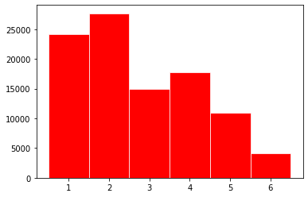

```python
fig, ax = plt.subplots()
ax.bar(x, y, width=1, color='r', edgecolor="white", linewidth=0.7)
plt.show()
```

```python
len(attributes_values.loc[attributes_values.Meaning == 'unknown'])
```

```
232
```

```python
unknown_meaning_attributes = attributes_values.loc[attributes_values.Meaning == 'unknown'].astype('str')
```

```python
unknown_meaning_attributes.Value.unique()
```

```
array(['-1', '-1, 0', '0', '-1, 9'], dtype=object)
```

```python
unknown_meaning_attributes = unknown_meaning_attributes.astype('str')
```

```python
def extract_attribute_unknown_category_values(unknown_meaning_attributes: pd.DataFrame, attribute: str):
    """extracts attribute unknown values to be later replaced"""
    # find pandas series for the unknown Value in given attribute
    unknown_values_series: pd.Series = unknown_meaning_attributes.loc[
        unknown_meaning_attributes["Attribute"] == attribute]["Value"]
    # from pandas series to normal str
    unknown_values_series = unknown_values_series.values[0]
    # seperate multiple values (if existed)
    unknown_values_list = [int(x) for x in unknown_values_series.split(",")]
    # return unknown value/seperated_values in the form of a list
    return [unknown_values_list]
```

```python
ALTERSKATEGORIE_GROB_unknown_values = extract_attribute_unknown_category_values(unknown_meaning_attributes, "ALTERSKATEGORIE_GROB")
```

```python
ALTERSKATEGORIE_GROB_unknown_values
```

```
[[-1, 0]]
```

```python
def replace_unknown_values_with_nan(val, unknown_category_values):
    if val in unknown_category_values:
        return np.nan
    return val
```

```python
def replace_all_unknown_values_with_nan(df):
    unknown_meaning_attributes = attributes_values.loc[attributes_values.Meaning == 'unknown'].astype('str')
    for col in unknown_meaning_attributes.Attribute:
        col_unknown_value = extract_attribute_unknown_category_values(unknown_meaning_attributes, col)
        if col in df.columns:
            df[col] = df[col].apply(replace_unknown_values_with_nan, args=(col_unknown_value))
    return df
```

```python
azdias = replace_all_unknown_values_with_nan(azdias)
```

```python
azdias.head()
```

|  | LNR | AGER_TYP | AKT_DAT_KL | ALTER_HH | ALTER_KIND1 | ALTER_KIND2 | ALTER_KIND3 | ALTER_KIND4 | ALTERSKATEGORIE_FEIN | ANZ_HAUSHALTE_AKTIV | ... | VHN | VK_DHT4A | VK_DISTANZ | VK_ZG11 | W_KEIT_KIND_HH | WOHNDAUER_2008 | WOHNLAGE | ZABEOTYP | ANREDE_KZ | ALTERSKATEGORIE_GROB |
| --- | --- | --- | --- | --- | --- | --- | --- | --- | --- | --- | --- | --- | --- | --- | --- | --- | --- | --- | --- | --- | --- |
| 0 | 910215 | NaN | NaN | NaN | NaN | NaN | NaN | NaN | NaN | NaN | ... | NaN | NaN | NaN | NaN | NaN | NaN | NaN | 3 | 1 | 2 |
| 1 | 910220 | NaN | 9.0 | 0.0 | NaN | NaN | NaN | NaN | 21.0 | 11.0 | ... | 4.0 | 8.0 | 11.0 | 10.0 | 3.0 | 9.0 | 4.0 | 5 | 2 | 1 |
| 2 | 910225 | NaN | 9.0 | 17.0 | NaN | NaN | NaN | NaN | 17.0 | 10.0 | ... | 2.0 | 9.0 | 9.0 | 6.0 | 3.0 | 9.0 | 2.0 | 5 | 2 | 3 |
| 3 | 910226 | 2.0 | 1.0 | 13.0 | NaN | NaN | NaN | NaN | 13.0 | 1.0 | ... | 0.0 | 7.0 | 10.0 | 11.0 | NaN | 9.0 | 7.0 | 3 | 2 | 4 |
| 4 | 910241 | NaN | 1.0 | 20.0 | NaN | NaN | NaN | NaN | 14.0 | 3.0 | ... | 2.0 | 3.0 | 5.0 | 4.0 | 2.0 | 9.0 | 3.0 | 4 | 1 | 3 |

5 rows × 366 columns

```python
customers = replace_all_unknown_values_with_nan(customers)
```

```python
customers.head()
```

|  | LNR | AGER_TYP | AKT_DAT_KL | ALTER_HH | ALTER_KIND1 | ALTER_KIND2 | ALTER_KIND3 | ALTER_KIND4 | ALTERSKATEGORIE_FEIN | ANZ_HAUSHALTE_AKTIV | ... | VK_ZG11 | W_KEIT_KIND_HH | WOHNDAUER_2008 | WOHNLAGE | ZABEOTYP | PRODUCT_GROUP | CUSTOMER_GROUP | ONLINE_PURCHASE | ANREDE_KZ | ALTERSKATEGORIE_GROB |
| --- | --- | --- | --- | --- | --- | --- | --- | --- | --- | --- | --- | --- | --- | --- | --- | --- | --- | --- | --- | --- | --- |
| 0 | 9626 | 2.0 | 1.0 | 10.0 | NaN | NaN | NaN | NaN | 10.0 | 1.0 | ... | 2.0 | 6.0 | 9.0 | 7.0 | 3.0 | COSMETIC_AND_FOOD | MULTI_BUYER | 0.0 | 1.0 | 4.0 |
| 1 | 9628 | NaN | 9.0 | 11.0 | NaN | NaN | NaN | NaN | NaN | NaN | ... | 3.0 | NaN | 9.0 | NaN | 3.0 | FOOD | SINGLE_BUYER | 0.0 | 1.0 | 4.0 |
| 2 | 143872 | NaN | 1.0 | 6.0 | NaN | NaN | NaN | NaN | 0.0 | 1.0 | ... | 11.0 | 6.0 | 9.0 | 2.0 | 3.0 | COSMETIC_AND_FOOD | MULTI_BUYER | 0.0 | 2.0 | 4.0 |
| 3 | 143873 | 1.0 | 1.0 | 8.0 | NaN | NaN | NaN | NaN | 8.0 | 0.0 | ... | 2.0 | NaN | 9.0 | 7.0 | 1.0 | COSMETIC | MULTI_BUYER | 0.0 | 1.0 | 4.0 |
| 4 | 143874 | NaN | 1.0 | 20.0 | NaN | NaN | NaN | NaN | 14.0 | 7.0 | ... | 4.0 | 2.0 | 9.0 | 3.0 | 1.0 | FOOD | MULTI_BUYER | 0.0 | 1.0 | 3.0 |

5 rows × 369 columns

```python
customers_null_data_frame = DescribeNulls(customers).construct_null_data_frame()
azdias_null_data_frame = DescribeNulls(azdias).construct_null_data_frame()
```

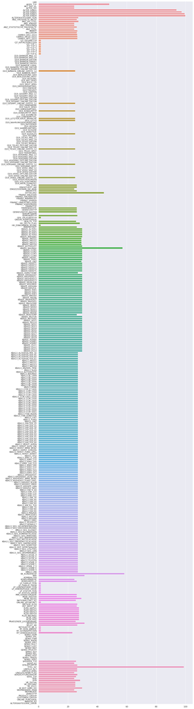

```python
sns.set(rc = {'figure.figsize':(15,70)})
ax = fig.add_subplot(121)
ax = sns.barplot(
    x=customers_null_data_frame.null_percentage.values,
    y=customers_null_data_frame.column_name.values,
)
```

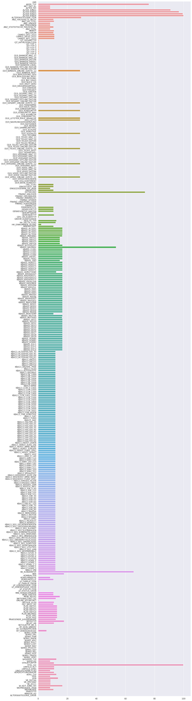

```python
sns.set(rc = {'figure.figsize':(15,70)})
ax = fig.add_subplot(553)
ax = sns.barplot(
    x=azdias_null_data_frame.null_percentage.values,
    y=azdias_null_data_frame.column_name.values,
)
```

```python
azdias_null_data_frame.null_percentage
```

```
0       0.000000
1      76.019640
2       8.247000
3       8.247000
4      90.904837
         ...
361     8.247000
362    10.451729
363     0.000000
364     0.000000
365     0.000000
Name: null_percentage, Length: 366, dtype: float64
```

```python
unnecessary_columns = azdias_null_data_frame.sort_values(
    "null_percentage",
    ascending=False).loc[azdias_null_data_frame.null_percentage > 20].column_name
```

```python
unnecessary_columns
```

```
7                      ALTER_KIND4
349                       TITEL_KZ
6                      ALTER_KIND3
5                      ALTER_KIND2
4                      ALTER_KIND1
1                         AGER_TYP
100                      EXTSEL992
300                   KK_KUNDENTYP
129                   KBA05_BAUMAX
8             ALTERSKATEGORIE_FEIN
85     D19_VERSAND_ONLINE_QUOTE_12
62                       D19_LOTTO
77       D19_TELKO_ONLINE_QUOTE_12
36      D19_BANKEN_ONLINE_QUOTE_12
53      D19_GESAMT_ONLINE_QUOTE_12
57                   D19_KONSUMTYP
61        D19_LETZTER_KAUF_BRANCHE
92       D19_VERSI_ONLINE_QUOTE_12
69                    D19_SOZIALES
Name: column_name, dtype: object
```

```python
azdias = azdias.drop(columns=[*unnecessary_columns])
```

```python
azdias.shape
```

```
(891221, 347)
```

```python
customers = customers.drop(columns=[*unnecessary_columns])
```

```python
customers.shape
```

```
(191328, 350)
```

```python
azdias.info()
```

```
<class 'pandas.core.frame.DataFrame'>
RangeIndex: 891221 entries, 0 to 891220
Columns: 347 entries, LNR to ALTERSKATEGORIE_GROB
dtypes: float64(257), int64(87), object(3)
memory usage: 2.3+ GB
```

```python
customers.info()
```

```
<class 'pandas.core.frame.DataFrame'>
RangeIndex: 191328 entries, 0 to 191327
Columns: 350 entries, LNR to ALTERSKATEGORIE_GROB
dtypes: float64(273), int64(69), object(8)
memory usage: 510.9+ MB
```

```python
azdias_object_cols = azdias.columns[azdias.dtypes == "object"]
customer_object_cols = customers.columns[customers.dtypes == "object"]
```

```python
print("Azdias columns with dtype Object \n", azdias_object_cols.values)
print("Customer columns with dtype Object \n", customer_object_cols.values)
```

[output not shown]

```python
col = azdias_object_cols.values[1]
col
```

```
'EINGEFUEGT_AM'
```

```python
attributes_info[attributes_info.Attribute == col]
```

|  | index | Information level | Attribute | Description | Additional notes |
| --- | --- | --- | --- | --- | --- |

```python
attributes_values[attributes_values.Attribute == col]
```

|  | index | Attribute | Description | Value | Meaning |
| --- | --- | --- | --- | --- | --- |

```python
def fix_LP_cols(df):
    """
    Function to replace 0s with nan values columns,
    ["LP_FAMILIE_FEIN", "LP_FAMILIE_GROB", "LP_LEBENSPHASE_FEIN",
           "LP_LEBENSPHASE_GROB", "LP_STATUS_FEIN", "LP_STATUS_GROB"]
    """

    # Replacing '0' with NaNs
    cols = ["LP_FAMILIE_FEIN", "LP_FAMILIE_GROB", "LP_LEBENSPHASE_FEIN",
           "LP_LEBENSPHASE_GROB", "LP_STATUS_FEIN", "LP_STATUS_GROB"]

    df[cols] = df[cols].replace({0: np.nan})
    df[cols] = df[cols].astype(float)



    # LP_FAMILIE_GROB
    convert_1 = {1: 'single', 2: 'couple', 3: 'singleparent', 4: 'singleparent', 5: 'singleparent',
                  6: 'family', 7: 'family', 8: 'family', 9: 'multihousehold', 10: 'multihousehold', 11: 'multihousehold'}
    convert_2 = {'single':0, 'couple':1, 'singleparent':2, 'family':3, 'multihousehold':4}

    df["LP_FAMILIE_GROB"] = df["LP_FAMILIE_GROB"].map(convert_1)
    df["LP_FAMILIE_GROB"] = df["LP_FAMILIE_GROB"].map(convert_2)

    # LP_STATUS_GROB
    convert_1 = {1: 'lowincome', 2: 'lowincome', 3: 'avgincome', 4: 'avgincome', 5: 'avgincome',
                  6: 'independant', 7: 'independant', 8: 'houseowner', 9: 'houseowner', 10: 'topearner'}
    convert_2 = {'lowincome':0, 'avgincome':1, 'independant':2, 'houseowner':3, 'topearner':4}

    df["LP_STATUS_GROB"] = df["LP_STATUS_GROB"].map(convert_1)
    df["LP_STATUS_GROB"] = df["LP_STATUS_GROB"].map(convert_2)


    # LP_LEBENSPHASE_FEIN
    life_stages = {1: 'younger_age', 2: 'middle_age', 3: 'younger_age',
              4: 'middle_age', 5: 'advanced_age', 6: 'retirement_age',
              7: 'advanced_age', 8: 'retirement_age', 9: 'middle_age',
              10: 'middle_age', 11: 'advanced_age', 12: 'retirement_age',
              13: 'advanced_age', 14: 'younger_age', 15: 'advanced_age',
              16: 'advanced_age', 17: 'middle_age', 18: 'younger_age',
              19: 'advanced_age', 20: 'advanced_age', 21: 'middle_age',
              22: 'middle_age', 23: 'middle_age', 24: 'middle_age',
              25: 'middle_age', 26: 'middle_age', 27: 'middle_age',
              28: 'middle_age', 29: 'younger_age', 30: 'younger_age',
              31: 'advanced_age', 32: 'advanced_age', 33: 'younger_age',
              34: 'younger_age', 35: 'younger_age', 36: 'advanced_age',
              37: 'advanced_age', 38: 'retirement_age', 39: 'middle_age',
              40: 'retirement_age'}

    wealth_scale = {1: 'low', 2: 'low', 3: 'average', 4: 'average', 5: 'low', 6: 'low',
              7: 'average', 8: 'average', 9: 'average', 10: 'wealthy', 11: 'average',
              12: 'average', 13: 'top', 14: 'average', 15: 'low', 16: 'average',
              17: 'average', 18: 'wealthy', 19: 'wealthy', 20: 'top', 21: 'low',
              22: 'average', 23: 'wealthy', 24: 'low', 25: 'average', 26: 'average',
              27: 'average', 28: 'top', 29: 'low', 30: 'average', 31: 'low',
              32: 'average', 33: 'average', 34: 'average', 35: 'top', 36: 'average',
              37: 'average', 38: 'average', 39: 'top', 40: 'top'}

    df["Temp"] = df["LP_LEBENSPHASE_FEIN"]

    df["LP_LEBENSPHASE_FEIN"] = df["LP_LEBENSPHASE_FEIN"].map(life_stages)
    df["LP_LEBENSPHASE_GROB"] = df["Temp"].map(wealth_scale)

    life_stages = {'younger_age': 1, 'middle_age': 2, 'advanced_age': 3,
            'retirement_age': 4}
    wealth_scale = {'low': 1, 'average': 2, 'wealthy': 3, 'top': 4}

    df["LP_LEBENSPHASE_FEIN"] = df["LP_LEBENSPHASE_FEIN"].map(life_stages)
    df["LP_LEBENSPHASE_GROB"] = df["LP_LEBENSPHASE_GROB"].map(wealth_scale)


    return df
```

```python
customers["EINGEFUEGT_AM"]=pd.to_datetime(customers["EINGEFUEGT_AM"], format='%Y-%m-%d %H:%M:%S', errors='coerce')
```

```python
customers["EINGEFUEGT_AM"].value_counts()
```

```
1992-02-10    64604
1992-02-12    43592
2003-11-18     1061
2005-12-16      807
1995-02-07      569
              ...
2013-06-06        1
2009-03-23        1
1995-06-30        1
2005-02-15        1
2008-07-14        1
Name: EINGEFUEGT_AM, Length: 3029, dtype: int64
```

```python
azdias["EINGEFUEGT_AM"] = pd.to_datetime(azdias["EINGEFUEGT_AM"], format='%Y-%m-%d %H:%M:%S', errors='coerce')
```

```python
azdias['year']=azdias['EINGEFUEGT_AM'].dt.year
```

```python
customers['year']=customers['EINGEFUEGT_AM'].dt.year
```

```python
customers.groupby(['year']).count()['LNR'].sort_values()
```

```
year
2016.0        10
2015.0       165
1999.0       166
2014.0       223
2001.0       259
2013.0       283
2010.0       284
2011.0       342
2012.0       356
2009.0       485
2002.0       539
1998.0       545
2008.0       579
2007.0       648
2006.0       895
2000.0       955
2004.0      1101
2003.0      1693
2005.0      2149
1994.0      2812
1997.0      3652
1993.0      3875
1996.0      5092
1995.0      5649
1992.0    108666
Name: LNR, dtype: int64
```

```python
azdias_object_cols.values[1]
```

```
'EINGEFUEGT_AM'
```

```python
azdias.columns[azdias.dtypes == "object"]
```

```
Index(['CAMEO_DEU_2015', 'OST_WEST_KZ'], dtype='object')
```

```python
customers.columns[customers.dtypes == "object"]
```

```
Index(['CAMEO_DEU_2015', 'EWDICHTE', 'KBA05_KRSHERST3', 'KBA05_KRSKLEIN',
       'OST_WEST_KZ', 'PRODUCT_GROUP', 'CUSTOMER_GROUP'],
      dtype='object')
```

```python
customers=customers.drop(columns='CAMEO_DEU_2015')
azdias=azdias.drop(columns='CAMEO_DEU_2015')
```

```python
customers.groupby('OST_WEST_KZ').count()
```

| OST_WEST_KZ | LNR | AKT_DAT_KL | ALTER_HH | ANZ_HAUSHALTE_AKTIV | ANZ_HH_TITEL | ANZ_KINDER | ANZ_PERSONEN | ANZ_STATISTISCHE_HAUSHALTE | ANZ_TITEL | ARBEIT | ... | W_KEIT_KIND_HH | WOHNDAUER_2008 | WOHNLAGE | ZABEOTYP | PRODUCT_GROUP | CUSTOMER_GROUP | ONLINE_PURCHASE | ANREDE_KZ | ALTERSKATEGORIE_GROB | year |
| --- | --- | --- | --- | --- | --- | --- | --- | --- | --- | --- | --- | --- | --- | --- | --- | --- | --- | --- | --- | --- | --- |
| O | 11319 | 11319 | 11319 | 11319 | 11245 | 11319 | 11319 | 11319 | 11319 | 11319 | ... | 10689 | 11319 | 11319 | 11319 | 11319 | 11319 | 11319 | 11319 | 11319 | 11319 |
| W | 130104 | 130104 | 130104 | 130104 | 128001 | 130104 | 130104 | 130104 | 130104 | 129555 | ... | 122817 | 130104 | 130104 | 130104 | 130104 | 130104 | 130104 | 130104 | 130104 | 130104 |

2 rows × 349 columns

```python
attributes_values[attributes_values.Attribute=='EWDICHTE']
```

|  | index | Attribute | Description | Value | Meaning |
| --- | --- | --- | --- | --- | --- |
| 647 | 647 | EWDICHTE | density of inhabitants per square kilometer | -1 | unknown |
| 648 | 648 | EWDICHTE | NaN | 1 | less than 34 HH/km² |
| 649 | 649 | EWDICHTE | NaN | 2 | 34 - 89 HH/km² |
| 650 | 650 | EWDICHTE | NaN | 3 | 90 - 149 HH/km² |
| 651 | 651 | EWDICHTE | NaN | 4 | 150 - 319 HH/km² |
| 652 | 652 | EWDICHTE | NaN | 5 | 320 - 999 HH/km² |
| 653 | 653 | EWDICHTE | NaN | 6 | more than 999 HH/² |

```python
customers=customers.drop(columns='EWDICHTE')
azdias=azdias.drop(columns='EWDICHTE')
```

```python
attributes_values[attributes_values.Attribute=='KBA05_KRSKLEIN'].Description.values[0]
```

```
'share of small cars (referred to the county average)'
```

```python
customers=customers.drop(columns='KBA05_KRSKLEIN')
azdias=azdias.drop(columns='KBA05_KRSKLEIN')
```

```python
attributes_values[attributes_values.Attribute=='KBA05_KRSHERST3'].Description.values[0]
```

```
'share of Ford/Opel (reffered to the county average)'
```

```python
customers=customers.drop(columns='KBA05_KRSHERST3')
azdias=azdias.drop(columns='KBA05_KRSHERST3')
```

```python
attributes_info[attributes_info.Attribute=='KBA13_ANTG1'].Description.values
```

```
array([], dtype=object)
```

```python
customers.KBA13_ANTG1.value_counts()
```

```
2.0    57301
3.0    49152
1.0    19143
4.0    13947
0.0      532
Name: KBA13_ANTG1, dtype: int64
```

```python
customers=customers.drop(columns='KBA13_ANTG1')
azdias=azdias.drop(columns='KBA13_ANTG1')
```

```python
customers=customers.drop(columns='KBA13_HERST_EUROPA')
azdias=azdias.drop(columns='KBA13_HERST_EUROPA')
```

```python
customers=customers.drop(columns='KBA13_HERST_FORD_OPEL')
azdias=azdias.drop(columns='KBA13_HERST_FORD_OPEL')
```

```python
customers.columns[customers.dtypes == "object"]
```

```
Index(['OST_WEST_KZ', 'PRODUCT_GROUP', 'CUSTOMER_GROUP'], dtype='object')
```

```python
customers.info()
```

```
<class 'pandas.core.frame.DataFrame'>
RangeIndex: 191328 entries, 0 to 191327
Columns: 344 entries, LNR to year
dtypes: datetime64[ns](1), float64(271), int64(69), object(3)
memory usage: 502.1+ MB
```

```python
azdias.info()
```

```
<class 'pandas.core.frame.DataFrame'>
RangeIndex: 891221 entries, 0 to 891220
Columns: 341 entries, LNR to year
dtypes: datetime64[ns](1), float64(252), int64(87), object(1)
memory usage: 2.3+ GB
```

### Select the rows that have the minimum amount of values

```python
# number of columns
azdias.shape[1], customers.shape[1]
```

```
(341, 344)
```

```python
def select_rows_with_low_nan(data_frame: pd.DataFrame, nan_number_threshold: int = 150) -> pd.DataFrame:
    """Threshold default is 150
    For the customers table is (150/364=0.4) 40% of the columns
    For the azdias table is (150/361=0.4) 40% as well"""
    nan_series = data_frame.isnull().sum(axis=1)
    data_frame = data_frame[nan_series <= nan_number_threshold]
    return data_frame
```

```python
customers = select_rows_with_low_nan(customers)
```

```python
azdias = select_rows_with_low_nan(azdias)
```

```python
# remaining rows
total_rows_azdias, total_rows_customers = (azdias.shape[0], customers.shape[0])
total_rows_azdias, total_rows_customers
```

```
(791244, 140568)
```

```python
attributes_values[attributes_values.Attribute == 'WOHNLAGE']
```

|  | index | Attribute | Description | Value | Meaning |
| --- | --- | --- | --- | --- | --- |
| 2229 | 2229 | WOHNLAGE | residential-area | -1 | unknown |
| 2230 | 2230 | WOHNLAGE | NaN | 0 | no score calculated |
| 2231 | 2231 | WOHNLAGE | NaN | 1 | very good neighbourhood |
| 2232 | 2232 | WOHNLAGE | NaN | 2 | good neighbourhood |
| 2233 | 2233 | WOHNLAGE | NaN | 3 | average neighbourhood |
| 2234 | 2234 | WOHNLAGE | NaN | 4 | poor neighbourhood |
| 2235 | 2235 | WOHNLAGE | NaN | 5 | very poor neighbourhood |
| 2236 | 2236 | WOHNLAGE | NaN | 7 | rural neighbourhood |
| 2237 | 2237 | WOHNLAGE | NaN | 8 | new building in rural neighbourhood |

```python
attributes_info[attributes_info.Attribute == 'WOHNLAGE']
```

|  | index | Information level | Attribute | Description | Additional notes |
| --- | --- | --- | --- | --- | --- |
| 84 | 84 | NaN | WOHNLAGE | neighbourhood-area (very good -> rather poor; ... | NaN |

```python
customers.WOHNLAGE.value_counts() / total_rows_customers, azdias.WOHNLAGE.value_counts() / total_rows_azdias
```

```
(3.0    0.318671
 7.0    0.221779
 2.0    0.172628
 1.0    0.117274
 4.0    0.106432
 5.0    0.041503
 8.0    0.015338
 0.0    0.006374
 Name: WOHNLAGE, dtype: float64,
 3.0    0.313746
 7.0    0.213030
 4.0    0.170831
 2.0    0.126144
 5.0    0.093318
 1.0    0.055150
 8.0    0.020978
 0.0    0.006802
 Name: WOHNLAGE, dtype: float64)
```

#### 31% of the customers have average neighborhood.

```python
customers['WOHNLAGE']=customers.WOHNLAGE.replace({0: np.nan})
azdias['WOHNLAGE']=azdias.WOHNLAGE.replace({0: np.nan})
```

```python
len(azdias[azdias.WOHNLAGE.isnull()])/len(azdias)
```

[output not shown]

```python
azdias.OST_WEST_KZ.unique()
```

```
array(['W', 'O'], dtype=object)
```

## Label Encoding

```python
customers['ANREDE_KZ'].value_counts()
```

```
1.0    94096
2.0    46472
Name: ANREDE_KZ, dtype: int64
```

```python
customers['OST_WEST_KZ'].value_counts()
```

```
W    129329
O     11239
Name: OST_WEST_KZ, dtype: int64
```

```python
customers['CAMEO_DEUG_2015'].value_counts()
```

```
2.0    23390
4.0    21941
6.0    18598
3.0    18246
1.0    16701
8.0    12955
5.0    11551
7.0    10481
9.0     6324
Name: CAMEO_DEUG_2015, dtype: int64
```

```python
attributes_values[attributes_values.Attribute=='CAMEO_DEUG_2015']
```

|  | index | Attribute | Description | Value | Meaning |
| --- | --- | --- | --- | --- | --- |
| 51 | 51 | CAMEO_DEUG_2015 | CAMEO classification 2015 - Uppergroup | -1 | unknown |
| 52 | 52 | CAMEO_DEUG_2015 | NaN | 1 | upper class |
| 53 | 53 | CAMEO_DEUG_2015 | NaN | 2 | upper middleclass |
| 54 | 54 | CAMEO_DEUG_2015 | NaN | 3 | established middleclasse |
| 55 | 55 | CAMEO_DEUG_2015 | NaN | 4 | consumption-oriented middleclass |
| 56 | 56 | CAMEO_DEUG_2015 | NaN | 5 | active middleclass |
| 57 | 57 | CAMEO_DEUG_2015 | NaN | 6 | low-consumption middleclass |
| 58 | 58 | CAMEO_DEUG_2015 | NaN | 7 | lower middleclass |
| 59 | 59 | CAMEO_DEUG_2015 | NaN | 8 | working class |
| 60 | 60 | CAMEO_DEUG_2015 | NaN | 9 | urban working class |

#### The "CAMEO_INTL_2015" attribute has two features. The household feature that ranges between the following list:

#### [Wealthy, Prosperous, Comfortable, Less Affluent, Poorer]

#### And the Family [Couples & Singles, Couples With Children, Families With School Age Children, Families & Mature Couples, Elders In Retirement]

```python
def features_division(feature_name: str, data_frame: pd.DataFrame, *args) -> pd.DataFrame:
    data_frame[args[0]]= data_frame[feature_name].apply(lambda x: np.floor_divide(float(x), 10) if float(x) else np.nan)
    data_frame[args[1]] = data_frame[feature_name].apply(lambda x: np.mod(float(x), 10) if float(x) else np.nan)
    return data_frame

customers = features_division('CAMEO_INTL_2015',
                                   customers,
                                   'household_status',
                                   'family_status',)
```

```python
def label_encoding(data_frame: pd.DataFrame) -> pd.DataFrame:
    cleanup_dict = {
        "OST_WEST_KZ": {"W": 1, "O": 0},
        "ANREDE_KZ": {1: 0, 2: 1}
    }
    return data_frame.replace(cleanup_dict)
```

```python
customers = label_encoding(customers)
```

```python
azdias = features_division('CAMEO_INTL_2015',
                                   azdias,
                                   'household_status',
                                   'family_status',)
azdias = label_encoding(azdias)
```

```python
azdias['EINGEFUEGT_AM'].value_counts()
```

```
1992-02-10    383182
1992-02-12    192015
1995-02-07     11178
2005-12-16      6207
2003-11-18      6049
               ...
2010-04-27         1
2011-10-04         1
2007-10-03         1
2006-04-18         1
2005-03-19         1
Name: EINGEFUEGT_AM, Length: 4474, dtype: int64
```

```python
attributes_values[attributes_values.Attribute=='D19_LETZTER_KAUF_BRANCHE']
```

|  | index | Attribute | Description | Value | Meaning |
| --- | --- | --- | --- | --- | --- |

```python
columns_list=['LNR', 'EINGEFUEGT_AM']
azdias=azdias.drop(columns=columns_list)
customers=customers.drop(columns=columns_list)
```

```python
azdias.info()
```

```
<class 'pandas.core.frame.DataFrame'>
Int64Index: 791244 entries, 1 to 891220
Columns: 341 entries, AKT_DAT_KL to family_status
dtypes: float64(254), int64(87)
memory usage: 2.0 GB
```

```python
uncommon_columns = []
common_columns = []
for i in customers.columns:
    if i in azdias.columns:
        common_columns.append(i)
        continue
    uncommon_columns.append(i)
```

```python
uncommon_columns
```

```
['PRODUCT_GROUP', 'CUSTOMER_GROUP', 'ONLINE_PURCHASE']
```

```python
customers[common_columns].info()
```

```
<class 'pandas.core.frame.DataFrame'>
Int64Index: 140568 entries, 0 to 191327
Columns: 341 entries, AKT_DAT_KL to family_status
dtypes: float64(272), int64(69)
memory usage: 370.8 MB
```

```python
import numpy as np
from sklearn.impute import SimpleImputer
imp_most_frequent = SimpleImputer(missing_values=np.nan, strategy='most_frequent')
imp_customers = pd.DataFrame(imp_most_frequent.fit_transform(customers[common_columns]), columns=customers[common_columns].columns)
```

```python
customers_file_name = 'ArvatoDataset/Preprocessed_Udacity_CUSTOMERS.csv'
imp_customers.to_csv(customers_file_name, index=False)
customers_upload_data_prefix = "Arvato_Capstone/Preprocessed_Udacity_CUSTOMERS.csv"
with open(customers_file_name, "rb") as f:
    s3.upload_fileobj(f, downloaded_data_bucket, customers_upload_data_prefix)
```

```python
imp_most_frequent = SimpleImputer(missing_values=np.nan, strategy='most_frequent')
azdias = pd.DataFrame(imp_most_frequent.fit_transform(azdias), columns=azdias.columns)
```

```python
azdias_file_name = 'ArvatoDataset/Preprocessed_Udacity_AZDIAS.csv'
azdias.to_csv(azdias_file_name, index=False)
azdias_upload_data_prefix = "Arvato_Capstone/Preprocessed_Udacity_AZDIAS.csv"
with open(azdias_file_name, "rb") as f:
    s3.upload_fileobj(f, downloaded_data_bucket, azdias_upload_data_prefix)
```

```python
imp_customers.info()
```

```
<class 'pandas.core.frame.DataFrame'>
RangeIndex: 140568 entries, 0 to 140567
Columns: 341 entries, AKT_DAT_KL to family_status
dtypes: float64(341)
memory usage: 365.7 MB
```

# PCA

### Computing PCA via the covariance matrix

```python
from sklearn.preprocessing import StandardScaler
```

```python
imp_customers.info()
```

```
<class 'pandas.core.frame.DataFrame'>
RangeIndex: 140568 entries, 0 to 140567
Columns: 341 entries, AKT_DAT_KL to family_status
dtypes: float64(341)
memory usage: 365.7 MB
```

```python
# extract the vectors from the azdias table
azdias_values = azdias.values
customers_values = imp_customers.values

# standardise the data
azdias_std = StandardScaler().fit_transform(azdias_values)
customers_std = StandardScaler().fit_transform(customers_values)
```

```python
azdias_std
```

```
array([[ 1.25850288, -1.42547704,  0.17176172, ..., -0.43463668,
         1.17697271, -1.25115185],
       [ 1.25850288,  0.80168563,  0.10789254, ..., -0.43463668,
        -0.8689364 ,  0.76528928],
       [-0.93889228,  0.27764735, -0.46693004, ...,  0.89871086,
        -1.5509061 , -0.57900481],
       ...,
       [-0.93889228,  0.80168563, -0.33919169, ..., -0.43463668,
        -0.8689364 ,  0.76528928],
       [ 1.25850288, -1.42547704, -0.08371498, ..., -0.43463668,
         1.17697271, -1.25115185],
       [-0.93889228, -1.42547704,  0.10789254, ..., -0.43463668,
         0.49500301,  0.09314223]])
```

```python
# subtract the mean vector from each vector in the dataset
means = np.mean(azdias_values, axis=0)
X_sm = azdias_std - means
```

```python
X_cov = X_sm.T.dot(X_sm) / (X_sm.shape[0] - 1)

# Side-note: Numpy has a function for computing the covariance matrix
X_cov2 = np.cov(azdias_std.T)
print("X_cov == X_cov2: ", np.allclose(X_cov, X_cov2))

# perform the eigendecomposition of the covariance matrix
eig_vals, eig_vecs = np.linalg.eig(X_cov2)
```

[output not shown]

#### What remains now is to pick the eigenvectors (columns in eig_vecs) associated with the eigenvalues in eig_vals with the highest absolute values.

```python
def percvar(v):
    r"""Transform eigen/singular values into percents.
    Return: vector of percents, prefix vector of percents
    """
    # sort values
    s = np.sort(np.abs(v))
    # reverse sorting order
    s = s[::-1]
    # normalize
    s = s/np.sum(s)
    return s, np.cumsum(s)
print("eigenvalues:    ", eig_vals)
pct, pv = percvar(eig_vals)
print("percent values: ", pct)
print("prefix vector:  ", pv)
```

```
eigenvalues:     [ 2.91138007e+01  1.76544447e+01  1.66765370e+01  1.28209331e+01
  8.29101810e+00  7.13610444e+00  6.44687517e+00  6.08344997e+00
  5.29770350e+00  4.88798870e+00  4.37524240e+00  4.23947961e+00
  3.93533416e+00  3.60323297e+00  3.44918907e+00  3.28030012e+00
  3.23370501e+00  3.15295192e+00  3.05783048e+00  2.92982593e+00
  2.69666925e+00  2.67849451e+00  2.62679302e+00  2.45651309e+00
  2.34025883e+00  2.30187077e+00  2.18884875e+00  2.13131096e+00
  2.07956708e+00  2.05619322e+00  2.04075092e+00  1.98157192e+00
  1.96320170e+00  1.87295948e+00  1.83998202e+00  1.78564609e+00
  1.75575417e+00  1.69975599e+00  1.65332405e+00  1.62424023e+00
  1.57792218e+00  1.57139552e+00  1.55477406e+00  1.48864956e+00
  1.44586860e+00  1.42598128e+00  1.39956193e+00  1.38305155e+00
  1.37323801e+00  1.34497190e+00  1.33856533e+00  1.32125388e+00
  1.28574613e+00  1.27937355e+00  1.26291163e+00  1.24561706e+00
  1.23238278e+00  1.21913574e+00  1.19958375e+00  1.18757448e+00
  1.15130689e+00  1.13871729e+00  1.12395135e+00  1.12008761e+00
  1.10728771e+00  1.09492265e+00  1.04071110e+00  1.08238010e+00
  1.05755418e+00  1.06806403e+00  1.06449953e+00  1.02035548e+00
  1.01274724e+00  1.00175081e+00  1.00054311e+00  9.97515553e-01
  9.97372687e-01  9.77770519e-01  9.74395845e-01  9.69213618e-01
  9.63069111e-01  9.61078705e-01  8.53158796e-01  9.46831248e-01
  9.44229462e-01  8.60388128e-01  8.67159005e-01  8.74001827e-01
  8.79689660e-01  8.81685889e-01  8.90397589e-01  8.97234036e-01
  9.02263032e-01  9.13094885e-01  9.15729173e-01  9.21682998e-01
  9.32431404e-01  9.29307948e-01  9.31419614e-01  8.61402675e-01
  8.45438703e-01  8.42666998e-01  8.35444965e-01  8.32388502e-01
  8.28795161e-01  8.23465217e-01  8.20248304e-01  8.13577892e-01
  8.10085936e-01  8.04040772e-01  7.93304898e-01  7.89578633e-01
  7.71255511e-01  7.82318665e-01  7.78732192e-01  7.76770406e-01
  7.63988303e-01  7.60867432e-01  7.57442900e-01  7.11265663e-01
  7.17482540e-01  7.23082688e-01  7.26812199e-01  7.34302202e-01
  7.35429407e-01  7.47754114e-01  7.45289736e-01  7.45674335e-01
  4.69999039e-03  6.98081781e-03  7.04897361e-01  6.66457728e-01
  6.98602292e-01  6.97006572e-01  6.72583120e-01  6.91460536e-01
  6.87967820e-01  6.84707715e-01  6.81197357e-01  6.78499613e-01
  1.05070467e-02  6.62899249e-01  6.60875618e-01  6.53371978e-01
  6.51790764e-01  6.48064737e-01  6.45028974e-01  6.37659129e-01
  6.59551105e-01  6.18922920e-01  6.21597565e-01  6.24731640e-01
  6.26525767e-01  1.20526617e-02  1.67255561e-02  2.17082811e-02
  2.18312069e-02  5.00915080e-01  5.05461341e-01  5.17274590e-01
```

[output cut: 174 more lines]

```
 0.97405574 0.9746078  0.97515705 0.97568603 0.97621314 0.97673218
 0.97724989 0.9777589  0.97826393 0.97876097 0.97925302 0.97974286
 0.98022642 0.9807041  0.98117342 0.98163751 0.98208988 0.98253145
 0.98296878 0.98340388 0.983832   0.98425459 0.98466684 0.98507369
 0.98547884 0.98587482 0.98626795 0.98665246 0.98703433 0.98741245
 0.98778786 0.98815748 0.98852172 0.98888118 0.9892288  0.98956723
 0.98990331 0.99023448 0.99056323 0.99089024 0.9912142  0.991535
 0.99185201 0.99216438 0.99246749 0.99276836 0.99305101 0.99333166
 0.9936108  0.9938858  0.99415099 0.99441163 0.99466507 0.99491674
 0.99516622 0.99541205 0.99565403 0.9958916  0.99612668 0.99635833
 0.99658492 0.99681066 0.99703505 0.99725604 0.99747388 0.99769108
 0.99790145 0.99810739 0.99831001 0.99847163 0.99863218 0.99878594
 0.99892685 0.99905983 0.99919035 0.99931977 0.99944796 0.99955981
 0.99964294 0.99972286 0.99978688 0.99985054 0.99989959 0.99993493
 0.99996575 0.99998622 1.         1.         1.        ]
```

#### Plotting the pct and pv vectors and observe the general trend of the variance as more and more dimensions are added.

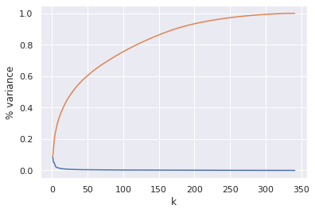

```python
# plot feature and overall percent variance
%matplotlib inline
import matplotlib.pyplot as plt
plt.plot(range(1, len(pct)+1), pct, label="feature")
plt.plot(range(1, len(pv)+1), pv, label="overall")
plt.ylabel('% variance')
plt.xlabel('k')
plt.show()
```

#### Now, given an expected percent variance , we choose the number of features with at least that percent explained variance value in the vector , i.e., the first dimension whose value is greater or equal to the desired percent.

```python
def perck(s, p):
    for i in range(len(s)):
        if s[i] >= p:
            return i+1  # human readable number of features
    return len(s)

for p in [90, 95]:
    print("Number of dimensions to account for %d%% of the variance: %d" % (p, perck(pv, p*0.01)))

ninety_five_percent_of_variation = perck(pv, 95*0.01)
ninety_five_percent_of_variation
```

```
Number of dimensions to account for 90% of the variance: 173
Number of dimensions to account for 95% of the variance: 218
```

```
218
```

```python
from sklearn.decomposition import PCA
pca = PCA(ninety_five_percent_of_variation, random_state=21321231)
pca.fit(azdias_std)
azdias_data_transformed = pca.transform(azdias_std)
azdias_data_transformed
```

```
array([[-4.90063557, -1.60303461,  6.70151439, ...,  0.16888857,
        -0.43459227, -0.22934917],
       [ 0.4066937 , -2.98604944,  1.42289567, ...,  0.41941371,
         0.18914105,  0.25028939],
       [ 4.16565112, -5.2493447 , -3.06153013, ..., -0.66370638,
        -0.87386006,  0.18753151],
       ...,
       [ 3.28222988,  1.78277904,  3.26400304, ...,  0.36000339,
        -0.55298504, -1.10130598],
       [-7.51532427,  5.93860009, -0.08812147, ...,  0.35127258,
        -0.10621759, -0.05718734],
       [-0.95520887, -4.63250225, -4.36850669, ...,  0.07099796,
         0.54428487, -0.36404848]])
```

```python
len(pca.components_)
```

```
218
```

```python
def plot_feature_weights(df, pca, attributes_info, dimension, n_weights = 5, plot=True,figsize=(7,8)):
    """
    This function displays interesting features of the selected dimension
    """

    features = df.columns.values
    components = pca.components_
    feature_weights = dict(zip(features, components[dimension]))
    sorted_weights = sorted(feature_weights.items(), key = lambda kv: kv[1])

    feat_names = []
    feat_weights = []
    feat_descs = []

    for feature, weight in sorted_weights[-n_weights:]:
        feat_names.append(feature)
        feat_weights.append(weight)

    for feature, weight, in sorted_weights[:n_weights]:
        feat_names.append(feature)
        feat_weights.append(weight)

    for feature in feat_names:
        if feature in attributes_info.Attribute.values:
            feat_descs.append(attributes_info[attributes_info.Attribute == feature].Description.values[0])
        else:
            feat_descs.append("No description given")

    component_info = {"Feature":feat_names, "Description":feat_descs, "FeatureWeight":feat_weights}
    component_info = pd.DataFrame(component_info)
    component_info.sort_values("FeatureWeight", inplace=True, ascending=False, ignore_index=True)

    if plot:
        fig = plt.figure(figsize=figsize)

        ax = fig.add_subplot(211)
        ax.bar(feat_names, feat_weights)
        ax.set_ylabel("Feature Weight")
        ax.set_xlabel("Feature Name")
        ax.set_title("PCA Feature weights - Component {}".format(dimension))
        for tick in ax.get_xticklabels():
            tick.set_rotation(45)
        ax.grid()

        fig.tight_layout()
        plt.show()

    return component_info
```

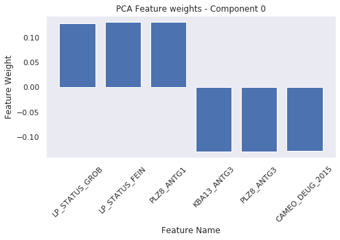

|  | Feature | Description | FeatureWeight |
| --- | --- | --- | --- |
| 0 | PLZ8_ANTG1 | number of 1-2 family houses in the PLZ8 | 0.130386 |
| 1 | LP_STATUS_FEIN | social status fine | 0.130322 |
| 2 | LP_STATUS_GROB | social status rough | 0.127967 |
| 3 | CAMEO_DEUG_2015 | CAMEO_4.0: uppergroup | -0.128886 |
| 4 | PLZ8_ANTG3 | number of 6-10 family houses in the PLZ8 | -0.129098 |
| 5 | KBA13_ANTG3 | No description given | -0.129146 |

```python
component_0_info = plot_feature_weights(azdias, pca, attributes_info, 0, 3)
component_0_info.head(10)
```

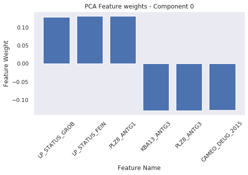

|  | Feature | Description | FeatureWeight |
| --- | --- | --- | --- |
| 0 | PLZ8_ANTG1 | number of 1-2 family houses in the PLZ8 | 0.130386 |
| 1 | LP_STATUS_FEIN | social status fine | 0.130322 |
| 2 | LP_STATUS_GROB | social status rough | 0.127967 |
| 3 | CAMEO_DEUG_2015 | CAMEO_4.0: uppergroup | -0.128886 |
| 4 | PLZ8_ANTG3 | number of 6-10 family houses in the PLZ8 | -0.129098 |
| 5 | KBA13_ANTG3 | No description given | -0.129146 |

```python
component_1_info = plot_feature_weights(azdias, pca, attributes_info, 0, 3)
component_1_info.head(10)
```

```python
from sklearn.cluster import KMeans
from yellowbrick.cluster import KElbowVisualizer
```

```
findfont: Font family ['sans-serif'] not found. Falling back to DejaVu Sans.
```

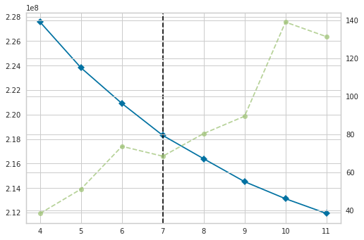

```python
model = KMeans()
visualizer = KElbowVisualizer(
    model, k=(4, 12), metric='distortion').fit(azdias_data_transformed)
```

```python
SEED: int = 1321
kmeans = KMeans(7, random_state=SEED)
kmeans.fit(azdias_data_transformed)
```

```
KMeans(n_clusters=7, random_state=1321)
```

```python
azdias_cluster = kmeans.predict(azdias_data_transformed)
```

```python
np.unique(azdias_cluster)
```

```
array([0, 1, 2, 3, 4, 5, 6], dtype=int32)
```

```python
customers_transformed_data = pca.transform(customers_std)
```

```python
customers_cluster = kmeans.predict(customers_transformed_data)
```

```python
print(azdias_cluster[:15], "\n", customers_cluster[:15])
```

```
[0 0 2 6 2 0 0 5 5 4 6 0 4 0 0]
 [2 4 2 1 5 2 5 1 6 6 6 6 1 5 6]
```

```python
customers_cluster = pd.Series(customers_cluster)
azdias_cluster = pd.Series(azdias_cluster)
```

```python
customers_cluster.value_counts().sort_index()
```

```
0    16633
1    13120
2    31828
3     7541
4    24657
5    20456
6    26333
dtype: int64
```

```python
azdias_cluster.value_counts().sort_index()
```

```
0    127827
1    112024
2    135838
3     79558
4    116456
5     76307
6    143234
dtype: int64
```

```python
cluster_info = pd.DataFrame([])

cluster_info["Population"] = azdias_clusters.value_counts().sort_index()
cluster_info["Customers"] = customers_clusters.value_counts().sort_index()
cluster_info.reset_index(inplace=True)
cluster_info.rename(columns={"index":"Cluster"}, inplace=True)
```

```python
cluster_info
```

|  | Cluster | Population | Customers |
| --- | --- | --- | --- |
| 0 | 0 | 127827 | 16633 |
| 1 | 1 | 112024 | 13120 |
| 2 | 2 | 135838 | 31828 |
| 3 | 3 | 79558 | 7541 |
| 4 | 4 | 116456 | 24657 |
| 5 | 5 | 76307 | 20456 |
| 6 | 6 | 143234 | 26333 |

```
findfont: Font family ['sans-serif'] not found. Falling back to DejaVu Sans.
findfont: Font family ['sans-serif'] not found. Falling back to DejaVu Sans.
findfont: Font family ['sans-serif'] not found. Falling back to DejaVu Sans.
```

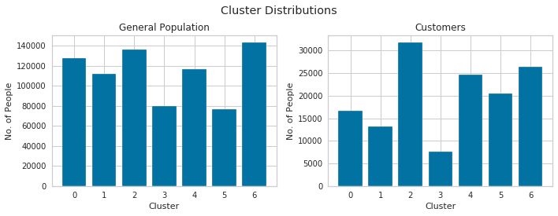

```python
fig, (ax1, ax2) = plt.subplots(1,2, figsize=(10, 4))

ax1.bar(cluster_info["Cluster"], cluster_info["Population"])
ax1.set_xlabel("Cluster")
ax1.set_ylabel("No. of People")
ax1.set_title("General Population")

ax2.bar(cluster_info["Cluster"], cluster_info["Customers"])
ax2.set_xlabel("Cluster")
ax2.set_ylabel("No. of People")
ax2.set_title("Customers")

fig.suptitle("Cluster Distributions")
fig.tight_layout(rect=[0, 0.03, 1, 0.95])
plt.show()
```

```python
cluster_info["Pop_proportion"] = (cluster_info["Population"]/cluster_info["Population"].sum()*100).round(3)
cluster_info["Cust_proportion"] = (cluster_info["Customers"]/cluster_info["Customers"].sum()*100).round(3)
```

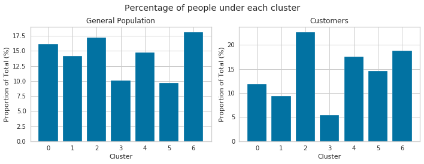

```python
fig, (ax1, ax2) = plt.subplots(1,2, figsize=(10, 4))

ax1.bar(cluster_info["Cluster"], cluster_info["Pop_proportion"])
ax1.set_xlabel("Cluster")
ax1.set_ylabel("Proportion of Total (%)")
ax1.set_title("General Population")

ax2.bar(cluster_info["Cluster"], cluster_info["Cust_proportion"])
ax2.set_xlabel("Cluster")
ax2.set_ylabel("Proportion of Total (%)")
ax2.set_title("Customers")

fig.suptitle("Percentage of people under each cluster")
fig.tight_layout(rect=[0, 0.03, 1, 0.95])
plt.show()
```

#### The distribution of general population is close to uniform (although not perfectly uniform).

#### The customers are mostly from clusters 0, 2, 4, 5, 6.

```python
cluster_info["Cust_over_Pop"] = cluster_info["Cust_proportion"] / cluster_info["Pop_proportion"]
```

```python
cluster_info
```

|  | Cluster | Population | Customers | Pop_proportion | Cust_proportion | Cust_over_Pop |
| --- | --- | --- | --- | --- | --- | --- |
| 0 | 0 | 127827 | 16633 | 16.155 | 11.833 | 0.732467 |
| 1 | 1 | 112024 | 13120 | 14.158 | 9.334 | 0.659274 |
| 2 | 2 | 135838 | 31828 | 17.168 | 22.642 | 1.318849 |
| 3 | 3 | 79558 | 7541 | 10.055 | 5.365 | 0.533565 |
| 4 | 4 | 116456 | 24657 | 14.718 | 17.541 | 1.191806 |
| 5 | 5 | 76307 | 20456 | 9.644 | 14.552 | 1.508917 |
| 6 | 6 | 143234 | 26333 | 18.102 | 18.733 | 1.034858 |

#### The ratio of more than 1 indicates that this cluster has a higher ratio of customers. And that this cluster of people in the population are very promising and are potentially the future customers.

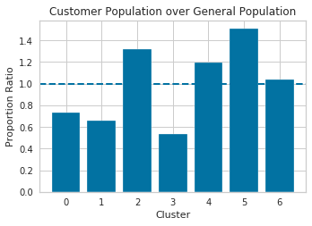

```python
fig, ax = plt.subplots(1,1, figsize=(5, 4))

ax.bar(cluster_info["Cluster"], cluster_info["Cust_over_Pop"])
ax.set_xlabel("Cluster")
ax.set_ylabel("Proportion Ratio")
ax.set_title("Customer Population over General Population")
ax.axhline(y=1, linestyle = "--", linewidth = 2)

fig.tight_layout(rect=[0, 0.03, 1, 0.95])
plt.show()
```

```python
def explain_cluster(kmeans_model, cluster_no, data, pca_model, attributes_info, num_components=2, num_feat_per_comp=3):

    weights = kmeans_model.cluster_centers_[cluster_no]
    components = list(range(len(weights)))

    cluster_expl = pd.DataFrame({"Weights":weights, "Component":components})
    cluster_expl.sort_values("Weights", ascending=False, inplace=True, ignore_index=True)

    comps = []
    weights = []
    comp_infos = []
    for index, row in cluster_expl.head(n=num_components).iterrows():

        component_info = plot_feature_weights(data, pca_model, attributes_info,
                                                int(row["Component"]), num_feat_per_comp, False)
        comp_infos.append(component_info)
        comps += [int(row["Component"])] * len(component_info)
        weights +=  [row["Weights"]] * len(component_info)

    component_info = pd.concat(comp_infos, ignore_index=True)
    component_info.insert(0, "ComponentWeight", pd.Series(weights))
    component_info.insert(0, "Component", pd.Series(comps))

    return component_info
```

```python
cluster_2 = explain_cluster(kmeans, 2, azdias, pca, attributes_info)
cluster_2
```

|  | Component | ComponentWeight | Feature | Description | FeatureWeight |
| --- | --- | --- | --- | --- | --- |
| 0 | 0 | 3.732936 | PLZ8_ANTG1 | number of 1-2 family houses in the PLZ8 | 0.130386 |
| 1 | 0 | 3.732936 | LP_STATUS_FEIN | social status fine | 0.130322 |
| 2 | 0 | 3.732936 | LP_STATUS_GROB | social status rough | 0.127967 |
| 3 | 0 | 3.732936 | CAMEO_DEUG_2015 | CAMEO_4.0: uppergroup | -0.128886 |
| 4 | 0 | 3.732936 | PLZ8_ANTG3 | number of 6-10 family houses in the PLZ8 | -0.129098 |
| 5 | 0 | 3.732936 | KBA13_ANTG3 | No description given | -0.129146 |
| 6 | 9 | 0.443429 | KBA13_ALTERHALTER_45 | share of car owners between 31 and 45 within t... | 0.173200 |
| 7 | 9 | 0.443429 | KBA13_HALTER_40 | share of car owners between 36 and 40 within t... | 0.168979 |
| 8 | 9 | 0.443429 | KBA13_KMH_140_210 | share of cars with max speed between 140 and 2... | 0.155800 |
| 9 | 9 | 0.443429 | PLZ8_HHZ | number of households within the PLZ8 | -0.128777 |
| 10 | 9 | 0.443429 | KBA13_HALTER_60 | share of car owners between 56 and 60 within t... | -0.132272 |
| 11 | 9 | 0.443429 | KBA13_ANZAHL_PKW | number of cars in the PLZ8 | -0.157974 |

```python
cluster_4 = explain_cluster(kmeans, 4, azdias, pca, attributes_info)
cluster_4
```

|  | Component | ComponentWeight | Feature | Description | FeatureWeight |
| --- | --- | --- | --- | --- | --- |
| 0 | 3 | 1.956715 | FINANZ_VORSORGER | financial typology: be prepared | 0.132438 |
| 1 | 3 | 1.956715 | ALTERSKATEGORIE_GROB | age through prename analysis | 0.126983 |
| 2 | 3 | 1.956715 | CJT_TYP_5 | No description given | 0.116761 |
| 3 | 3 | 1.956715 | FINANZ_UNAUFFAELLIGER | financial typology: unremarkable | -0.139686 |
| 4 | 3 | 1.956715 | FINANZ_SPARER | financial typology: money saver | -0.142749 |
| 5 | 3 | 1.956715 | FINANZ_ANLEGER | financial typology: investor | -0.146322 |
| 6 | 8 | 1.196645 | KBA13_ALTERHALTER_61 | share of car owners elder than 60 within the PLZ8 | 0.219860 |
| 7 | 8 | 1.196645 | KBA13_HALTER_66 | share of car owners over 66 within the PLZ8 | 0.203648 |
| 8 | 8 | 1.196645 | KBA13_HALTER_65 | share of car owners between 61 and 65 within t... | 0.196846 |
| 9 | 8 | 1.196645 | KBA13_HALTER_35 | share of car owners between 31 and 35 within t... | -0.168065 |
| 10 | 8 | 1.196645 | KBA13_ALTERHALTER_30 | share of car owners below 31 within the PLZ8 | -0.170300 |
| 11 | 8 | 1.196645 | KBA13_ALTERHALTER_45 | share of car owners between 31 and 45 within t... | -0.180991 |

```python
cluster_5 = explain_cluster(kmeans, 5, azdias, pca, attributes_info)
cluster_5
```

|  | Component | ComponentWeight | Feature | Description | FeatureWeight |
| --- | --- | --- | --- | --- | --- |
| 0 | 2 | 4.194295 | KBA13_HERST_BMW_BENZ | share of BMW & Mercedes Benz within the PLZ8 | 0.149138 |
| 1 | 2 | 4.194295 | CJT_TYP_2 | No description given | 0.135161 |
| 2 | 2 | 4.194295 | KBA13_SEG_OBEREMITTELKLASSE | share of upper middle class cars and upper cla... | 0.131561 |
| 3 | 2 | 4.194295 | CJT_TYP_5 | No description given | -0.117188 |
| 4 | 2 | 4.194295 | KBA13_SITZE_5 | number of cars with 5 seats in the PLZ8 | -0.124560 |
| 5 | 2 | 4.194295 | CJT_TYP_3 | No description given | -0.126270 |
| 6 | 0 | 1.846548 | PLZ8_ANTG1 | number of 1-2 family houses in the PLZ8 | 0.130386 |
| 7 | 0 | 1.846548 | LP_STATUS_FEIN | social status fine | 0.130322 |
| 8 | 0 | 1.846548 | LP_STATUS_GROB | social status rough | 0.127967 |
| 9 | 0 | 1.846548 | CAMEO_DEUG_2015 | CAMEO_4.0: uppergroup | -0.128886 |
| 10 | 0 | 1.846548 | PLZ8_ANTG3 | number of 6-10 family houses in the PLZ8 | -0.129098 |
| 11 | 0 | 1.846548 | KBA13_ANTG3 | No description given | -0.129146 |

```python
cluster_6 = explain_cluster(kmeans, 6, azdias, pca, attributes_info)
cluster_6
```

|  | Component | ComponentWeight | Feature | Description | FeatureWeight |
| --- | --- | --- | --- | --- | --- |
| 0 | 0 | 6.589884 | PLZ8_ANTG1 | number of 1-2 family houses in the PLZ8 | 0.130386 |
| 1 | 0 | 6.589884 | LP_STATUS_FEIN | social status fine | 0.130322 |
| 2 | 0 | 6.589884 | LP_STATUS_GROB | social status rough | 0.127967 |
| 3 | 0 | 6.589884 | CAMEO_DEUG_2015 | CAMEO_4.0: uppergroup | -0.128886 |
| 4 | 0 | 6.589884 | PLZ8_ANTG3 | number of 6-10 family houses in the PLZ8 | -0.129098 |
| 5 | 0 | 6.589884 | KBA13_ANTG3 | No description given | -0.129146 |
| 6 | 1 | 3.700681 | ONLINE_AFFINITAET | online affinity | 0.127835 |
| 7 | 1 | 3.700681 | D19_GESAMT_ANZ_24 | No description given | 0.121540 |
| 8 | 1 | 3.700681 | FINANZ_ANLEGER | financial typology: investor | 0.118371 |
| 9 | 1 | 3.700681 | FINANZ_VORSORGER | financial typology: be prepared | -0.113434 |
| 10 | 1 | 3.700681 | D19_GESAMT_ONLINE_DATUM | actuality of the last transaction with the com... | -0.114915 |
| 11 | 1 | 3.700681 | KBA13_HERST_BMW_BENZ | share of BMW & Mercedes Benz within the PLZ8 | -0.117802 |

## Part 2: Supervised Learning Model

Now that you've found which parts of the population are more likely to be customers of the mail-order company, it's time to build a prediction model. Each of the rows in the "MAILOUT" data files represents an individual that was targeted for a mailout campaign. Ideally, we should be able to use the demographic information from each individual to decide whether or not it will be worth it to include that person in the campaign.

The "MAILOUT" data has been split into two approximately equal parts, each with almost 43 000 data rows. In this part, you can verify your model with the "TRAIN" partition, which includes a column, "RESPONSE", that states whether or not a person became a customer of the company following the campaign. In the next part, you'll need to create predictions on the "TEST" partition, where the "RESPONSE" column has been withheld.

```python
!python3 -m pip install xgboost
```

```
     ━━━━━━━━━━━━━━━━━━━━━━━━━━━━━━━━━━━━━━━ 255.9/255.9 MB 3.6 MB/s eta 0:00:0000:0100:01
WARNING: Running pip as the 'root' user can result in broken permissions and conflicting behaviour with the system package manager. It is recommended to use a virtual environment instead: https://pip.pypa.io/warnings/venv
```

```python
from sklearn.model_selection import train_test_split
from sklearn.linear_model import LogisticRegression
from sklearn.tree import DecisionTreeClassifier
from sklearn.ensemble import RandomForestClassifier
from sklearn.ensemble import GradientBoostingRegressor, AdaBoostRegressor
from sklearn.ensemble import AdaBoostClassifier, GradientBoostingClassifier
import xgboost as xgb
from sklearn.metrics import accuracy_score, roc_auc_score, confusion_matrix
```

```python
mailout_train = pd.read_csv('./Udacity_MAILOUT_052018_TRAIN.csv', sep=';')
```

```python
mailout_train.head()
```

|  | LNR | AGER_TYP | AKT_DAT_KL | ALTER_HH | ALTER_KIND1 | ALTER_KIND2 | ALTER_KIND3 | ALTER_KIND4 | ALTERSKATEGORIE_FEIN | ANZ_HAUSHALTE_AKTIV | ... | VK_DHT4A | VK_DISTANZ | VK_ZG11 | W_KEIT_KIND_HH | WOHNDAUER_2008 | WOHNLAGE | ZABEOTYP | RESPONSE | ANREDE_KZ | ALTERSKATEGORIE_GROB |
| --- | --- | --- | --- | --- | --- | --- | --- | --- | --- | --- | --- | --- | --- | --- | --- | --- | --- | --- | --- | --- | --- |
| 0 | 1763 | 2 | 1.0 | 8.0 | NaN | NaN | NaN | NaN | 8.0 | 15.0 | ... | 5.0 | 2.0 | 1.0 | 6.0 | 9.0 | 3.0 | 3 | 0 | 2 | 4 |
| 1 | 1771 | 1 | 4.0 | 13.0 | NaN | NaN | NaN | NaN | 13.0 | 1.0 | ... | 1.0 | 2.0 | 1.0 | 4.0 | 9.0 | 7.0 | 1 | 0 | 2 | 3 |
| 2 | 1776 | 1 | 1.0 | 9.0 | NaN | NaN | NaN | NaN | 7.0 | 0.0 | ... | 6.0 | 4.0 | 2.0 | NaN | 9.0 | 2.0 | 3 | 0 | 1 | 4 |
| 3 | 1460 | 2 | 1.0 | 6.0 | NaN | NaN | NaN | NaN | 6.0 | 4.0 | ... | 8.0 | 11.0 | 11.0 | 6.0 | 9.0 | 1.0 | 3 | 0 | 2 | 4 |
| 4 | 1783 | 2 | 1.0 | 9.0 | NaN | NaN | NaN | NaN | 9.0 | 53.0 | ... | 2.0 | 2.0 | 1.0 | 6.0 | 9.0 | 3.0 | 3 | 0 | 1 | 3 |

5 rows × 367 columns

```python
mailout_train.RESPONSE
```

```
0        0
1        0
2        0
3        0
4        0
        ..
42957    0
42958    0
42959    0
42960    0
42961    0
Name: RESPONSE, Length: 42962, dtype: int64
```

```
0    42430
1      532
Name: RESPONSE, dtype: int64
```

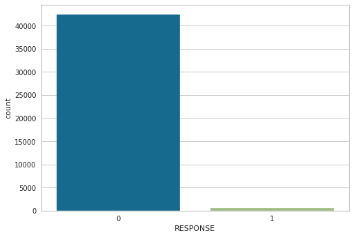

```python
print(mailout_train['RESPONSE'].value_counts())
sns.countplot("RESPONSE", data=mailout_train)
```

```python
def clean_data_for_supervised(cleaned_azdias, df, attributes_values):

    print("Cleaning Given Dataframe")

    start = time.time()

    # Forward fill attribute_values dataframe, to access required columns and corresponding info
    attributes_values["Attribute"] = attributes_values["Attribute"].ffill()

    # Fixing columns 18 and 19
    print("\tFixing 18, 19 columns")
    warning_cols = list(df.columns[18:20])

    # Ignore if these cols are already cleaned
    if not (df[warning_cols[0]].dtype == 'float64') & (df[warning_cols[1]].dtype == 'float64'):
        cols = ["CAMEO_DEUG_2015", "CAMEO_INTL_2015"]
        df = replace_undescirbable_values_with_nulls(df, cols)


    print("\tFixing LP_* columns")
    df = fix_LP_cols(df)

    print("\tFixing EINGEFUGT column")
    df["EINGEFUEGT_AM"] = pd.to_datetime(df["EINGEFUEGT_AM"], format='%Y-%m-%d %H:%M:%S', errors='coerce')
    df['year'] = df['EINGEFUEGT_AM'].dt.year

    # Replacing "Unkown" values with "np.nan"
    print("\tReplacing 'unkown' values with 'NaN'")
    unkown_attributes_values = attributes_values[attributes_values["Meaning"] == "unknown"]

    df = replace_all_unknown_values_with_nan(df)

    # label Encoding OST_WEST_KZ and ANREDE_KZ cols
    df = label_encoding(df)

    print("\tEncoding CAMEO_INT column")
    df = features_division('CAMEO_INTL_2015',
                                   df,
                                   'household_status',
                                   'family_status',)

    print("\tEncoding WOHNLAGE column")
    df['WOHNLAGE']=df.WOHNLAGE.replace({0: np.nan})


    # Dropping columns which are not in azdias
    print("\tDropping extra columns")
    cols_to_drop = [col for col in df.columns if col not in azdias.columns]
#     cols_to_drop += ["EINGEFUEGT_AM", "D19_LETZTER_KAUF_BRANCHE", "CAMEO_DEU_2015"]

    df = df.drop(cols_to_drop, axis = 1)


    # Imputing Missing data
    print("\tImputing missing values with most frequent ones")
    imputer = SimpleImputer(strategy="most_frequent")

    imputer.fit(azdias)
    df = pd.DataFrame(imputer.transform(df), columns = df.columns)

    end = time.time()

    print(f"Completed Cleaning in {end-start} seconds")

    return df
```

```python
labels = mailout_train["RESPONSE"]
mailout_train_LNR = mailout_train["LNR"]
```

```python
mailout_train = clean_data_for_supervised(azdias, mailout_train, attributes_values)
```

```
Cleaning Given Dataframe
	Fixing 18, 19 columns
	Fixing LP_* columns
	Fixing EINGEFUGT column
	Replacing 'unkown' values with 'NaN'
	Encoding CAMEO_INT column
	Encoding WOHNLAGE column
	Dropping extra columns
	Imputing missing values with most frequent ones
Completed Cleaning in 15.07287073135376 seconds
```

```python
X_train, X_val, y_train, y_val = train_test_split(mailout_train, labels, stratify=labels, test_size=0.2, random_state=SEED)
```

```python
lr = LogisticRegression(random_state=SEED)
```

```python
lr.fit(X_train, y_train)
```

```
LogisticRegression(random_state=1321)
```

```python
pred = lr.predict_proba(X_val)[:,1]
```

```python
pred
```

```
array([0.02796144, 0.00454981, 0.00932593, ..., 0.01476456, 0.01573498,
       0.00284927])
```

```python
print("Baseline AUROC - ", roc_auc_score(y_val, pred))
```

```
Baseline AUROC -  0.6474146919483962
```

#### Trying Different Models

```python
scaler = StandardScaler()
mailout_train = pd.DataFrame(scaler.fit_transform(mailout_train), columns = mailout_train.columns)
```

```python
X_train, X_val, y_train, y_val = train_test_split(mailout_train, labels, stratify=labels, test_size=0.2, random_state=SEED)
```

```python
def train_and_predict(model, X_train, y_train, X_test, y_test):
    """
    Fit a model on X_train, y_train
    predicts on X_text, y_test
    Calculate AUROC on predictions made on test data

    Outputs - AUROC score, time elapse for training and prediction
    """
    start = time.time()
    model = model.fit(X_train, y_train)

    roc_score = roc_auc_score(y_test, model.predict_proba(X_test)[:,1])

    end = time.time()
    time_elapsed = end - start

    return roc_score, time_elapsed
```

```python
models = [("LogisticRegression", LogisticRegression(random_state=SEED)),
         ("DecisionTreeClassifier", DecisionTreeClassifier(random_state=SEED)),
         ("RandomForestClassifier", RandomForestClassifier(random_state=SEED)),
         ("GradientBoostingClassifier", GradientBoostingClassifier(random_state=SEED)),
         ("AdaBoostClassifier", AdaBoostClassifier(random_state=SEED)),
         ("XGBClassifier",xgb.XGBClassifier(random_state=SEED))]
```

```python
results = {"Model":[],
          "AUCROC_score":[],
          "Time_in_sec":[]}

for name, model in models:
    roc, time_ = train_and_predict(model, X_train, y_train, X_val, y_val)
    results["Model"].append(name)
    results["AUCROC_score"].append(roc)
    results["Time_in_sec"].append(time_)
```

```python
results = pd.DataFrame.from_dict(results, orient='index').transpose()
results
```

|  | Model | AUCROC_score | Time_in_sec |
| --- | --- | --- | --- |
| 0 | LogisticRegression | 0.595523 | 1.424952 |
| 1 | DecisionTreeClassifier | 0.506376 | 2.745634 |
| 2 | RandomForestClassifier | 0.559654 | 10.128791 |
| 3 | GradientBoostingClassifier | 0.612495 | 47.139457 |
| 4 | AdaBoostClassifier | 0.58311 | 10.98397 |
| 5 | XGBClassifier | 0.5615 | 9.500488 |